# s01_explore_kgen_low_ddr_individuals

Started: David Gilfoyle 18 May 2018  
Updated: David Gilfoyle 21 May 2018

# Summary

Production of an additive genotype matrix and simple alt allele burden vector to allow assessment of 1000 Genomes Project individuals in the AF < 0.01 filtered dataset with a low DDR variant burden.

In order to reduce variants to workable levels, non-DDR gene variants and selected variants based on consequence are removed.

# start_section

```r
Sys.time()
```

```
## [1] "2018-05-21 17:32:06 UTC"
```

```r
rm(list=ls())
graphics.off()

# Install libraries
library(dplyr)
library(knitr)

# Make output wider (default was 80 columns?)
options(width = 100)
```

# load_rdata_file

```r
# Setup input folder
input_folder="/home/ec2-user/results/filtered/af_filt/kgen"

# Load RData file - contains dataframe containing all variants and genotype matrix
load(paste(input_folder, "r01_kgen_ddr_af_filtered.RData", sep="/"))

# Check remaining dataframe and matrix
dim(fixed_af_filt_kgen_ddr.df)
```

```
## [1] 312863     94
```

```r
class(fixed_af_filt_kgen_ddr.df)
```

```
## [1] "data.frame"
```

```r
fixed_af_filt_kgen_ddr.df[1:20,1:10]
```

```
##                CHROM     POS          ID REF ALT QUAL FILTER   AA AC          AF
## rs139644969_1      1 2114930 rs139644969   G   A  100   PASS g|||  1 0.000199681
## rs575517464_2      1 2114932 rs575517464   G   C  100   PASS g|||  3 0.000599042
## rs538360646_3      1 2114934 rs538360646   G   C  100   PASS g|||  1 0.000199681
## rs145208044_4      1 2114973 rs145208044   C   T  100   PASS c||| 16  0.00319489
## rs573512984_5      1 2115151 rs573512984   C   T  100   PASS c|||  1 0.000199681
## rs542455130_6      1 2115179 rs542455130   C   T  100   PASS c|||  1 0.000199681
## rs147616765_7      1 2115222 rs147616765   T   C  100   PASS t||| 14  0.00279553
## rs552449469_8      1 2115236 rs552449469   C   T  100   PASS c|||  3 0.000599042
## rs554482499_9      1 2115257 rs554482499   G   A  100   PASS g|||  3 0.000599042
## rs564910943_10     1 2115261 rs564910943   C   T  100   PASS c|||  7  0.00139776
## rs71630967_11      1 2115268  rs71630967   C   T  100   PASS c|||  8  0.00159744
## rs550697475_12     1 2115275 rs550697475   C   T  100   PASS c|||  1 0.000199681
## rs183894763_13     1 2115313 rs183894763   A   C  100   PASS a||| 27  0.00539137
## rs556783871_14     1 2115314 rs556783871 CTG   C  100   PASS <NA>  8  0.00159744
## rs148624904_15     1 2115342 rs148624904   C   A  100   PASS c|||  9  0.00179712
## rs566928140_17     1 2115401 rs566928140   G   C  100   PASS g|||  2 0.000399361
## rs539337032_18     1 2115408 rs539337032   G   A  100   PASS g|||  1 0.000199681
## rs569381728_19     1 2115411 rs569381728   G   C  100   PASS g|||  2 0.000399361
## rs188864364_20     1 2115432 rs188864364   G   A  100   PASS g||| 12  0.00239617
## rs538334300_21     1 2115435 rs538334300   T   G  100   PASS t||| 18  0.00359425
```

```r
dim(gt_af_filt_kgen_ddr.mx)
```

```
## [1] 312863   2504
```

```r
class(gt_af_filt_kgen_ddr.mx)
```

```
## [1] "matrix"
```

```r
gt_af_filt_kgen_ddr.mx[1:20,1:3]
```

```
##                HG00096 HG00097 HG00099
## rs139644969_1  "0|0"   "0|0"   "0|0"
## rs575517464_2  "0|0"   "0|0"   "0|0"
## rs538360646_3  "0|0"   "0|0"   "0|0"
## rs145208044_4  "0|0"   "0|0"   "0|0"
## rs573512984_5  "0|0"   "0|0"   "0|0"
## rs542455130_6  "0|0"   "0|0"   "0|0"
## rs147616765_7  "0|0"   "0|0"   "0|0"
## rs552449469_8  "0|0"   "0|0"   "0|0"
## rs554482499_9  "0|0"   "0|0"   "0|0"
## rs564910943_10 "0|0"   "0|0"   "0|0"
## rs71630967_11  "0|0"   "0|0"   "0|0"
## rs550697475_12 "0|0"   "0|0"   "0|0"
## rs183894763_13 "0|0"   "0|0"   "0|0"
## rs556783871_14 "0|0"   "0|0"   "0|0"
## rs148624904_15 "0|0"   "0|0"   "0|0"
## rs566928140_17 "0|0"   "0|0"   "0|0"
## rs539337032_18 "0|0"   "0|0"   "0|0"
## rs569381728_19 "0|0"   "0|0"   "0|0"
## rs188864364_20 "0|0"   "0|0"   "0|0"
## rs538334300_21 "0|0"   "0|0"   "0|0"
```

```r
# Check rowmnames are same
sum(rownames(gt_af_filt_kgen_ddr.mx) != rownames(fixed_af_filt_kgen_ddr.df)) # should be 0
```

```
## [1] 0
```

```r
# Setup base and output folders
base_folder="/home/ec2-user/scripts/data_analysis/gt_analysis"
output_folder="/home/ec2-user/results/data_analysis/gt_analysis"

getwd()
```

```
## [1] "/home/ec2-user/scripts/data_analysis/gt_analysis"
```

```r
setwd(base_folder)
getwd()
```

```
## [1] "/home/ec2-user/scripts/data_analysis/gt_analysis"
```

```r
opts_knit$set(root.dir = base_folder)
```

# variants_associated_with_ddr_genes

```r
# Set of DDR genes supporting variant filtration
ddr_genes <- c("UNG", "SMUG1", "MBD4", "TDG", "OGG1", "MUTYH", "NTHL1", "MPG", "NEIL1", "NEIL2", "NEIL3", "HMGB1", "APEX1", "APEX2", "LIG3", "XRCC1", "PNKP", "APLF", "PARP1", "PARP2", "PARP3", "MGMT", "ALKBH2", "ALKBH3", "TDP1", "TDP2", "MSH2", "MSH3", "MSH6", "MLH1", "PMS2", "MSH4", "MSH5", "MLH3", "PMS1", "PMS2P3", "XPC", "RAD23B", "CETN2", "RAD23A", "XPA", "DDB1", "DDB2", "RPA1", "RPA2", "RPA3", "ERCC3", "ERCC2", "GTF2H1", "GTF2H2", "GTF2H3", "GTF2H4", "GTF2H5", "CDK7", "CCNH", "MNAT1", "ERCC5", "ERCC1", "ERCC4", "LIG1", "RBX1", "CUL4A", "CUL4B", "ERCC8", "ERCC6", "UVSSA", "XAB2", "MMS19", "RAD51", "RAD51B", "RAD51D", "DMC1", "XRCC2", "XRCC3", "RAD52", "RAD54L", "RAD54B", "BRCA1", "SHFM1", "RAD50", "MRE11A", "NBN", "RBBP8", "MUS81", "EME1", "EME2", "SLX1A", "SLX1B", "GEN1", "BARD1", "BABAM1", "FAM175A", "BRE", "UIMC1", "BRCC3", "SYCP3", "FANCA", "FANCB", "FANCC", "BRCA2", "FANCD2", "FANCE", "FANCF", "FANCG", "FANCI", "BRIP1", "FANCL", "FANCM", "PALB2", "RAD51C", "SLX4", "C1orf86", "C19orf40", "APITD1", "WDR48", "USP1", "C17orf70", "HES1", "RMI1", "RMI2", "TOP3A", "UBE2T", "XRCC6", "XRCC5", "PRKDC", "LIG4", "XRCC4", "DCLRE1C", "NHEJ1", "DNTT", "NUDT1", "DUT", "RRM2B", "POLB", "POLG", "POLD1", "POLE", "PCNA", "REV3L", "MAD2L2", "REV1", "POLH", "POLI", "POLQ", "POLK", "POLL", "POLM", "POLN", "FEN1", "FAN1", "TREX1", "TREX2", "EXO1", "APTX", "SPO11", "ENDOV", "UBE2A", "UBE2B", "RAD18", "SHPRH", "HLTF", "RNF168", "SPRTN", "RNF8", "RNF4", "UBE2V2", "UBE2N", "H2AFX", "CHAF1A", "SETMAR", "BLM", "WRN", "RECQL4", "ATM", "MPLKIP", "DCLRE1A", "DCLRE1B", "RPA4", "PRPF19", "RECQL", "RECQL5", "HELQ", "RDM1", "NABP2", "RFC1", "RFC2", "RFC3", "RFC4", "RFC5", "ATR", "ATRIP", "MDC1", "RAD1", "RAD9A", "HUS1", "RAD17", "CHEK1", "CHEK2", "TP53", "TP53BP1", "RIF1", "TOPBP1", "CLK2", "PER1")

# Filtering of variants based on DDR genes using SYMBOL
fixed_af_filt_kgen_ddr.df <- tibble::rownames_to_column(fixed_af_filt_kgen_ddr.df, var = "rowname")
ddr_only.df <- fixed_af_filt_kgen_ddr.df %>%
  filter(fixed_af_filt_kgen_ddr.df$SYMBOL %in% ddr_genes)
ddr_only.df <- tibble::column_to_rownames(ddr_only.df, var = "rowname")

removed_variant.df <- fixed_af_filt_kgen_ddr.df %>%
  filter(!fixed_af_filt_kgen_ddr.df$SYMBOL %in% ddr_genes)

# Check output dataframe
dim(ddr_only.df)
```

```
## [1] 271021     94
```

```r
class(ddr_only.df)
```

```
## [1] "data.frame"
```

```r
ddr_only.df[1:20,1:10]
```

```
##                CHROM     POS          ID REF ALT QUAL FILTER   AA AC          AF
## rs373358003_45     1 2115988 rs373358003   G   A  100   PASS G|||  1 0.000199681
## rs45536443_46      1 2115989  rs45536443   C   T  100   PASS C|||  5 0.000998403
## rs192915352_47     1 2116005 rs192915352   C   T  100   PASS C|||  4 0.000798722
## rs143763676_48     1 2116070 rs143763676   G   C  100   PASS G|||  1 0.000199681
## rs554637318_49     1 2116075 rs554637318   C   T  100   PASS C|||  1 0.000199681
## rs56402864_50      1 2116114  rs56402864   C   G  100   PASS C|||  2 0.000399361
## rs185563823_51     1 2116175 rs185563823   C   T  100   PASS C||| 19  0.00379393
## rs377706761_52     1 2116191 rs377706761   A   G  100   PASS A|||  4 0.000798722
## rs532227319_53     1 2116267 rs532227319   G   A  100   PASS G|||  6  0.00119808
## rs45459595_54      1 2116287  rs45459595   C   T  100   PASS C||| 22  0.00439297
## rs563077886_55     1 2116288 rs563077886   G   A  100   PASS G|||  2 0.000399361
## rs531916201_56     1 2116291 rs531916201   C   T  100   PASS C|||  3 0.000599042
## rs548440022_57     1 2116292 rs548440022   G   C  100   PASS G|||  1 0.000199681
## rs112794083_58     1 2116299 rs112794083   C   T  100   PASS C||| 23  0.00459265
## rs200015308_59     1 2116347 rs200015308   A   G  100   PASS A|||  1 0.000199681
## rs143732365_60     1 2116357 rs143732365   A   G  100   PASS A|||  7  0.00139776
## rs570896635_61     1 2116418 rs570896635   A   G  100   PASS A|||  1 0.000199681
## rs116408566_62     1 2116433 rs116408566   C   T  100   PASS C|||  7  0.00139776
## rs367620589_63     1 2116453 rs367620589   G   A  100   PASS G|||  1 0.000199681
## rs190441951_64     1 2116454 rs190441951   C   T  100   PASS C|||  3 0.000599042
```

```r
class(ddr_only.df$SYMBOL)
```

```
## [1] "character"
```

```r
unique(ddr_only.df$SYMBOL)
```

```
##   [1] "C1orf86"  "MAD2L2"   "RPA2"     "MUTYH"    "RAD54L"   "USP1"     "MSH4"     "DCLRE1B"
##   [9] "CLK2"     "UBE2T"    "PARP1"    "SPRTN"    "EXO1"     "GEN1"     "BRE"      "MSH2"
##  [17] "MSH6"     "FANCL"    "APLF"     "REV1"     "ERCC3"    "RIF1"     "PMS1"     "BARD1"
##  [25] "XRCC5"    "NHEJ1"    "SETMAR"   "RAD18"    "OGG1"     "FANCD2"   "XPC"      "MLH1"
##  [33] "WDR48"    "ATRIP"    "TREX1"    "PARP3"    "POLQ"     "MBD4"     "TOPBP1"   "ATR"
##  [41] "HLTF"     "RFC4"     "HES1"     "RNF168"   "UVSSA"    "POLN"     "RNF4"     "RFC1"
##  [49] "HELQ"     "FAM175A"  "NEIL3"    "RAD1"     "ERCC8"    "CDK7"     "RAD17"    "GTF2H2"
##  [57] "POLK"     "MSH3"     "XRCC4"    "CCNH"     "RAD50"    "UBE2B"    "UIMC1"    "TDP2"
##  [65] "MDC1"     "GTF2H4"   "MSH5"     "FANCE"    "RNF8"     "POLH"     "REV3L"    "SHPRH"
##  [73] "GTF2H5"   "NUDT1"    "PMS2"     "RPA3"     "MPLKIP"   "POLM"     "HUS1"     "RFC2"
##  [81] "PMS2P3"   "SHFM1"    "XRCC2"    "NEIL2"    "WRN"      "POLB"     "PRKDC"    "UBE2V2"
##  [89] "NBN"      "RAD54B"   "RRM2B"    "APTX"     "FANCG"    "RMI1"     "FANCC"    "XPA"
##  [97] "RAD23B"   "DCLRE1C"  "ERCC6"    "DNTT"     "MMS19"    "POLL"     "DCLRE1A"  "MGMT"
## [105] "GTF2H1"   "FANCF"    "ALKBH3"   "DDB2"     "PRPF19"   "DDB1"     "FEN1"     "MUS81"
## [113] "RAD9A"    "MRE11A"   "ATM"      "H2AFX"    "CHEK1"    "RAD52"    "RECQL"    "SMUG1"
## [121] "NABP2"    "UBE2N"    "SYCP3"    "TDG"      "ALKBH2"   "UNG"      "RFC5"     "GTF2H3"
## [129] "POLE"     "HMGB1"    "BRCA2"    "RFC3"     "ERCC5"    "LIG4"     "CUL4A"    "PARP2"
## [137] "APEX1"    "FANCM"    "MNAT1"    "RAD51B"   "MLH3"     "TDP1"     "XRCC3"    "FAN1"
## [145] "RAD51"    "TP53BP1"  "DUT"      "NEIL1"    "FANCI"    "POLG"     "BLM"      "MPG"
## [153] "EME2"     "NTHL1"    "SLX4"     "RMI2"     "ERCC4"    "PALB2"    "SLX1B"    "SLX1A"
## [161] "FANCA"    "RPA1"     "TP53"     "PER1"     "TOP3A"    "LIG3"     "RAD51D"   "RDM1"
## [169] "BRCA1"    "EME1"     "RAD51C"   "BRIP1"    "RECQL5"   "ENDOV"    "C17orf70" "RBBP8"
## [177] "POLI"     "CHAF1A"   "XAB2"     "RAD23A"   "BABAM1"   "C19orf40" "XRCC1"    "ERCC2"
## [185] "ERCC1"    "LIG1"     "PNKP"     "POLD1"    "PCNA"     "SPO11"    "CHEK2"    "DMC1"
## [193] "RBX1"     "XRCC6"    "FANCB"    "APEX2"    "RPA4"     "UBE2A"    "CUL4B"    "CETN2"
## [201] "TREX2"    "BRCC3"
```

```r
unique(removed_variant.df$SYMBOL)
```

```
##   [1] "RP11-181G12.2"  NA               "AL590822.1"     "APITD1-CORT"    "CORT"
##   [6] "DFFA"           "FBXO6"          "DRAXIN"         "THEMIS2"        "HPDL"
##  [11] "TOE1"           "LRRC41"         "DOCK7"          "MAGI3"          "AP4B1"
##  [16] "SCAMP3"         "HCN3"           "EXOC8"          "SMC6"           "RBKS"
##  [21] "AC138655.6"     "KCNK12"         "AC079250.1"     "AC006509.4"     "AC006509.7"
##  [26] "RNU6-688P"      "FBXO11"         "VRK2"           "FBXO48"         "EIF5B"
##  [31] "NEB"            "SLC23A3"        "OXTR"           "hsa-mir-548ba"  "CAMK1"
##  [36] "TADA3"          "LSM3"           "EPM2AIP1"       "LRRFIP2"        "GORASP1"
##  [41] "SHISA5"         "RRP9"           "IFT122"         "EFCAB12"        "XRN1"
##  [46] "EIF4A2"         "CRIPAK"         "HAUS3"          "RP11-503N18.3"  "RP11-503N18.4"
##  [51] "WI2-89927D4.1"  "Y_RNA"          "FAM193A"        "WDR19"          "MRPS18C"
##  [56] "RPL30P5"        "RAI14"          "TTC23L"         "BRIX1"          "NDUFAF2"
##  [61] "CCDC125"        "TAF9"           "MARVELD2"       "NAIP"           "COL4A3BP"
##  [66] "DHFR"           "TMEM167A"       "RASA1"          "CDKL3"          "HK3"
##  [71] "ZNF346"         "KIAA0319"       "ACOT13"         "DPCR1"          "VARS2"
```

[output cut: 33 more lines]

# syncronise_ddr_variants_and_genotype_data_lof

```r
# Isolate relavent rows from genotype matrix
ddr_only.mx <- gt_af_filt_kgen_ddr.mx[rownames(ddr_only.df),]

# Compare filtered fixed column dataframe and genotype matrix
ddr_only.df[1:20,1:5]
```

```
##                CHROM     POS          ID REF ALT
## rs373358003_45     1 2115988 rs373358003   G   A
## rs45536443_46      1 2115989  rs45536443   C   T
## rs192915352_47     1 2116005 rs192915352   C   T
## rs143763676_48     1 2116070 rs143763676   G   C
## rs554637318_49     1 2116075 rs554637318   C   T
## rs56402864_50      1 2116114  rs56402864   C   G
## rs185563823_51     1 2116175 rs185563823   C   T
## rs377706761_52     1 2116191 rs377706761   A   G
## rs532227319_53     1 2116267 rs532227319   G   A
## rs45459595_54      1 2116287  rs45459595   C   T
## rs563077886_55     1 2116288 rs563077886   G   A
## rs531916201_56     1 2116291 rs531916201   C   T
## rs548440022_57     1 2116292 rs548440022   G   C
## rs112794083_58     1 2116299 rs112794083   C   T
## rs200015308_59     1 2116347 rs200015308   A   G
## rs143732365_60     1 2116357 rs143732365   A   G
## rs570896635_61     1 2116418 rs570896635   A   G
## rs116408566_62     1 2116433 rs116408566   C   T
## rs367620589_63     1 2116453 rs367620589   G   A
## rs190441951_64     1 2116454 rs190441951   C   T
```

```r
ddr_only.mx[1:20,1:2]
```

```
##                HG00096 HG00097
## rs373358003_45 "0|0"   "0|0"
## rs45536443_46  "0|0"   "0|0"
## rs192915352_47 "0|0"   "0|0"
## rs143763676_48 "0|0"   "0|0"
## rs554637318_49 "0|0"   "0|0"
## rs56402864_50  "0|0"   "0|0"
## rs185563823_51 "0|0"   "0|0"
## rs377706761_52 "0|0"   "0|0"
## rs532227319_53 "0|0"   "0|0"
## rs45459595_54  "0|0"   "0|0"
## rs563077886_55 "0|0"   "0|0"
## rs531916201_56 "0|0"   "0|0"
## rs548440022_57 "0|0"   "0|0"
## rs112794083_58 "0|0"   "0|0"
## rs200015308_59 "0|0"   "0|0"
## rs143732365_60 "0|0"   "0|0"
## rs570896635_61 "0|0"   "0|0"
## rs116408566_62 "0|0"   "0|0"
## rs367620589_63 "0|0"   "0|0"
## rs190441951_64 "0|0"   "0|0"
```

```r
# Check rowmnames are same
sum(rownames(ddr_only.mx) != rownames(ddr_only.df)) # should be 0
```

```
## [1] 0
```

```r
# Clean up
rm(fixed_af_filt_kgen_ddr.df, gt_af_filt_kgen_ddr.mx, removed_variant.df, ddr_genes)
```

# variant_filtering

Exclude selected variants assumed non-deleterious based on VEP consequences:  
1) synonymous  
2) intron variant  
3) upstream gene variant  
4) downstream gene variant  
5) intergenic variant  
6) 3’ UTR variant 7) 5’ UTR variant

3’ and 5’ UTR variants were filtered to allow screening of individuals from AFR sub-populations - high numbers of variants (including insertion / deletions)  
were observed in these variants - may have consequences on gene expression, although not considered for this assessment

```r
# Filtration based on consequence
ddr_only.df <- tibble::rownames_to_column(ddr_only.df, var = "rowname")
var_ddr_only.df <- ddr_only.df %>%
  filter(!grepl("synonymous_variant",Consequence)) %>%
  filter(!grepl("intron_variant",Consequence)) %>%
  filter(!grepl("upstream_gene_variant",Consequence)) %>%
  filter(!grepl("downstream_gene_variant",Consequence)) %>%
  filter(!grepl("intergenic_variant",Consequence)) %>%
  filter(!grepl("3_prime_UTR_variant",Consequence)) %>%
  filter(!grepl("5_prime_UTR_variant",Consequence))
var_ddr_only.df <- tibble::column_to_rownames(var_ddr_only.df, var = "rowname")

# Check removed variants
removed_variant.df <- ddr_only.df %>%
  filter(grepl("synonymous_variant",Consequence) |
           grepl("intron_variant",Consequence) |
           grepl("upstream_gene_variant",Consequence) |
           grepl("downstream_gene_variant",Consequence) |
           grepl("intergenic_variant",Consequence) |
           grepl("3_prime_UTR_variant",Consequence) |
           grepl("5_prime_UTR_variant",Consequence))

unique(removed_variant.df$Consequence)
```

```
##  [1] "downstream_gene_variant"
##  [2] "3_prime_UTR_variant"
##  [3] "intron_variant"
##  [4] "splice_region_variant&synonymous_variant"
##  [5] "synonymous_variant"
##  [6] "splice_region_variant&intron_variant"
##  [7] "upstream_gene_variant"
##  [8] "5_prime_UTR_variant"
##  [9] "splice_region_variant&5_prime_UTR_variant"
## [10] "coding_sequence_variant&5_prime_UTR_variant&intron_variant"
## [11] "coding_sequence_variant&5_prime_UTR_variant&3_prime_UTR_variant&intron_variant"
## [12] "intron_variant&feature_elongation"
## [13] "splice_donor_variant&intron_variant"
## [14] "coding_sequence_variant&intron_variant"
## [15] "coding_sequence_variant&3_prime_UTR_variant&intron_variant"
## [16] "coding_sequence_variant&intron_variant&feature_elongation"
## [17] "3_prime_UTR_variant&feature_elongation"
## [18] "intron_variant&non_coding_transcript_variant"
## [19] "splice_region_variant&intron_variant&non_coding_transcript_variant"
## [20] "5_prime_UTR_variant&intron_variant"
## [21] "splice_region_variant&3_prime_UTR_variant"
## [22] "coding_sequence_variant&5_prime_UTR_variant&intron_variant&feature_elongation"
```

```r
# Check output dataframe
dim(var_ddr_only.df)
```

```
## [1] 7657   94
```

```r
var_ddr_only.df[1:20,1:10]
```

```
##                  CHROM      POS          ID REF ALT QUAL FILTER   AA AC          AF
## rs114983157_376      1  2125086 rs114983157   G   C  100   PASS G|||  3 0.000599042
## rs200185087_377      1  2125123 rs200185087   G   A  100   PASS G|||  2 0.000399361
## rs200413325_379      1  2125205 rs200413325   C   A  100   PASS C||| 11  0.00219649
## rs561468605_380      1  2125322 rs561468605   C   T  100   PASS C|||  1 0.000199681
## rs568811969_384      1  2125463 rs568811969   G   C  100   PASS G|||  1 0.000199681
## rs552206271_385      1  2125495 rs552206271   A   G  100   PASS A|||  1 0.000199681
## rs144671392_387      1  2125540 rs144671392   C   G  100   PASS C||| 14  0.00279553
## rs146607591_388      1  2125543 rs146607591   A   G  100   PASS A|||  2 0.000399361
## rs573887985_389      1  2125552 rs573887985   C   G  100   PASS C|||  1 0.000199681
## rs559422464_1846     1 11735179 rs559422464   C   T  100   PASS C|||  1 0.000199681
## rs529770362_1847     1 11735232 rs529770362   C   T  100   PASS C|||  1 0.000199681
## rs151024263_1907     1 11736959 rs151024263   C   T  100   PASS C|||  3 0.000599042
## rs528545179_1931     1 11737620 rs528545179   C   T  100   PASS C|||  1 0.000199681
## rs146185443_2016     1 11740454 rs146185443   C   T  100   PASS C|||  1 0.000199681
## rs200358078_2018     1 11740466 rs200358078   C   T  100   PASS C|||  1 0.000199681
## rs565729007_2019     1 11740509 rs565729007   G   C  100   PASS G|||  1 0.000199681
## rs550898082_2416     1 28218693 rs550898082   T   C  100   PASS T|||  1 0.000199681
## rs28904899_2476      1 28220826  rs28904899   T   C  100   PASS T|||  1 0.000199681
## rs535763830_2551     1 28223565 rs535763830   A   G  100   PASS A|||  1 0.000199681
## rs556071176_2552     1 28223614 rs556071176   C   T  100   PASS C|||  1 0.000199681
```

```r
var_ddr_only.df$Consequence[1:20]
```

```
##  [1] "missense_variant"        "missense_variant"        "missense_variant"
##  [4] "missense_variant"        "missense_variant"        "missense_variant"
##  [7] "missense_variant"        "missense_variant"        "missense_variant"
## [10] "missense_variant"        "splice_acceptor_variant" "missense_variant"
## [13] "missense_variant"        "missense_variant"        "missense_variant"
## [16] "missense_variant"        "missense_variant"        "missense_variant"
## [19] "missense_variant"        "missense_variant"
```

```r
unique(var_ddr_only.df$Consequence)
```

```
##  [1] "missense_variant"
##  [2] "splice_acceptor_variant"
##  [3] "stop_gained"
##  [4] "splice_donor_variant"
##  [5] "missense_variant&splice_region_variant"
##  [6] "inframe_deletion"
##  [7] "frameshift_variant"
##  [8] "start_lost"
##  [9] "stop_gained&splice_region_variant"
## [10] "stop_lost"
## [11] "inframe_insertion"
## [12] "stop_retained_variant"
## [13] "non_coding_transcript_exon_variant"
## [14] "frameshift_variant&stop_lost"
## [15] "stop_gained&frameshift_variant&splice_region_variant"
```

# syncronise_filtered_variants_and_genotype_data_lof

```r
# Isolate relavent rows from genotype matrix
var_ddr_only.mx <- ddr_only.mx[rownames(var_ddr_only.df),]

# Compare filtered fixed column dataframe and genotype matrix
var_ddr_only.df[1:20,1:5]
```

```
##                  CHROM      POS          ID REF ALT
## rs114983157_376      1  2125086 rs114983157   G   C
## rs200185087_377      1  2125123 rs200185087   G   A
## rs200413325_379      1  2125205 rs200413325   C   A
## rs561468605_380      1  2125322 rs561468605   C   T
## rs568811969_384      1  2125463 rs568811969   G   C
## rs552206271_385      1  2125495 rs552206271   A   G
## rs144671392_387      1  2125540 rs144671392   C   G
## rs146607591_388      1  2125543 rs146607591   A   G
## rs573887985_389      1  2125552 rs573887985   C   G
## rs559422464_1846     1 11735179 rs559422464   C   T
## rs529770362_1847     1 11735232 rs529770362   C   T
## rs151024263_1907     1 11736959 rs151024263   C   T
## rs528545179_1931     1 11737620 rs528545179   C   T
## rs146185443_2016     1 11740454 rs146185443   C   T
## rs200358078_2018     1 11740466 rs200358078   C   T
## rs565729007_2019     1 11740509 rs565729007   G   C
## rs550898082_2416     1 28218693 rs550898082   T   C
## rs28904899_2476      1 28220826  rs28904899   T   C
## rs535763830_2551     1 28223565 rs535763830   A   G
## rs556071176_2552     1 28223614 rs556071176   C   T
```

```r
var_ddr_only.mx[1:20,1:2]
```

```
##                  HG00096 HG00097
## rs114983157_376  "0|0"   "0|0"
## rs200185087_377  "0|0"   "0|0"
## rs200413325_379  "0|0"   "0|0"
## rs561468605_380  "0|0"   "0|0"
## rs568811969_384  "0|0"   "0|0"
## rs552206271_385  "0|0"   "0|0"
## rs144671392_387  "0|0"   "0|0"
## rs146607591_388  "0|0"   "0|0"
## rs573887985_389  "0|0"   "0|0"
## rs559422464_1846 "0|0"   "0|0"
## rs529770362_1847 "0|0"   "0|0"
## rs151024263_1907 "0|0"   "0|0"
## rs528545179_1931 "0|0"   "0|0"
## rs146185443_2016 "0|0"   "0|0"
## rs200358078_2018 "0|0"   "0|0"
## rs565729007_2019 "0|0"   "0|0"
## rs550898082_2416 "0|0"   "0|0"
## rs28904899_2476  "0|0"   "0|0"
## rs535763830_2551 "0|0"   "0|0"
## rs556071176_2552 "0|0"   "0|0"
```

```r
# Check rowmnames are same
sum(rownames(var_ddr_only.mx) != rownames(var_ddr_only.df)) # should be 0
```

```
## [1] 0
```

```r
# Clean up
rm(ddr_only.df, ddr_only.mx, removed_variant.df)
```

# recode_genotypes_to_additive_numeric

0,1,2 for REF-REF, REF-ALT and ALT-ALT respectively  
Loosing phasing and hemizygous information

```r
# Prepare matrix of NA-s
gt_add.mx <- matrix(NA,
                    nrow=nrow(var_ddr_only.mx),
                    ncol=ncol(var_ddr_only.mx))

colnames(gt_add.mx) <- colnames(var_ddr_only.mx)
rownames(gt_add.mx) <- rownames(var_ddr_only.mx)

dim(gt_add.mx)
```

```
## [1] 7657 2504
```

```r
gt_add.mx[1:5,1:5]
```

```
##                 HG00096 HG00097 HG00099 HG00100 HG00101
## rs114983157_376      NA      NA      NA      NA      NA
## rs200185087_377      NA      NA      NA      NA      NA
## rs200413325_379      NA      NA      NA      NA      NA
## rs561468605_380      NA      NA      NA      NA      NA
## rs568811969_384      NA      NA      NA      NA      NA
```

```r
# explore the source matrix
var_ddr_only.mx[1:5,1:5]
```

```
##                 HG00096 HG00097 HG00099 HG00100 HG00101
## rs114983157_376 "0|0"   "0|0"   "0|0"   "0|0"   "0|0"
## rs200185087_377 "0|0"   "0|0"   "0|0"   "0|0"   "0|0"
## rs200413325_379 "0|0"   "0|0"   "0|0"   "0|0"   "0|0"
## rs561468605_380 "0|0"   "0|0"   "0|0"   "0|0"   "0|0"
## rs568811969_384 "0|0"   "0|0"   "0|0"   "0|0"   "0|0"
```

```r
# summary(as.factor(var_ddr_only.mx)) # long run time > 12 hours
sum(is.na(var_ddr_only.mx))
```

```
## [1] 0
```

```r
# populate the new matrix
0 -> gt_add.mx[ var_ddr_only.mx == "0"]
0 -> gt_add.mx[ var_ddr_only.mx == "0|0"]
1 -> gt_add.mx[ var_ddr_only.mx == "1"]
1 -> gt_add.mx[ var_ddr_only.mx == "0|1"]
1 -> gt_add.mx[ var_ddr_only.mx == "1|0"]
2 -> gt_add.mx[ var_ddr_only.mx == "1|1"]

# check result
dim(gt_add.mx)
```

```
## [1] 7657 2504
```

```r
gt_add.mx[1:5,1:5]
```

```
##                 HG00096 HG00097 HG00099 HG00100 HG00101
## rs114983157_376       0       0       0       0       0
## rs200185087_377       0       0       0       0       0
## rs200413325_379       0       0       0       0       0
## rs561468605_380       0       0       0       0       0
## rs568811969_384       0       0       0       0       0
```

```r
# summary(as.factor(gt_add.mx)) # long run time > 12 hours
sum(is.na(gt_add.mx))
```

```
## [1] 0
```

```r
# clean up
rm(meta.df)
```

# count_variants_burden_per_individual

Make and keep the named vector for later use

```r
# count
simple_burden <- apply(gt_add.mx, 2, sum)
names(simple_burden) <- colnames(gt_add.mx)

# explore
simple_burden[1:5]
```

```
## HG00096 HG00097 HG00099 HG00100 HG00101
##       4       4       8      13       8
```

```r
sum(is.na(simple_burden)) # sanity check
```

```
## [1] 0
```

```r
table(simple_burden)
```

```
## simple_burden
##   0   1   2   3   4   5   6   7   8   9  10  11  12  13  14  15  16  17  18  19  20  21  22  23  24
##   1   7  19  27 101 156 227 239 243 244 200 157 121 129  93  86  79  69  49  46  46  50  32  28  25
##  25  26  28  29  30  31  34  36
##  10   9   5   2   1   1   1   1
```

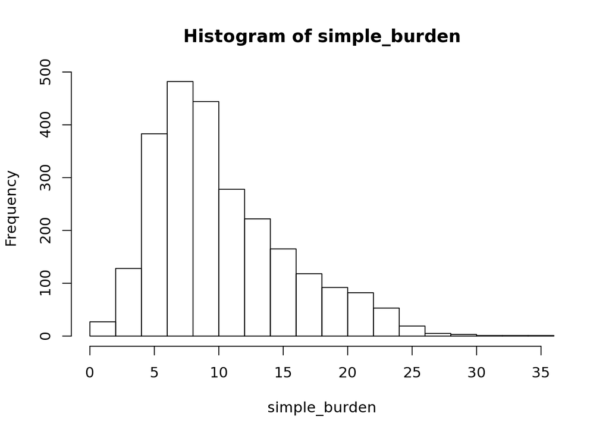

```r
hist(simple_burden)
```

```r
which(simple_burden == 0) # 0 alleles - 1 subject
```

```
## HG02067
##     771
```

```r
which(simple_burden == 1) # 1 allele - 7 subjects
```

```
## HG00449 HG00698 HG00956 HG02017 NA12341 NA19734 NA20810
##     203     288     315     746    1714    2210    2388
```

```r
which(simple_burden == 2) # 2 alleles - 19 subjects
```

```
## HG00442 HG00457 HG00610 HG01055 HG01124 HG01253 HG01577 HG01669 HG01936 HG01954 HG02150 HG03228
##     198     206     251     328     368     409     533     568     700     712     817    1239
## HG04056 NA12234 NA18614 NA19728 NA20540 NA20847 NA20904
##    1591    1704    1837    2206    2330    2404    2449
```

```r
which(simple_burden == 3) # 3 alleles - 27 subjects
```

```
## HG00120 HG00254 HG00350 HG00353 HG00581 HG00622 HG01497 HG01926 HG01982 HG02131 HG02775 HG02786
##      23      92     158     160     238     257     500     695     727     803    1076    1081
## HG02792 HG03779 HG03812 HG04025 HG04202 NA11930 NA18631 NA19006 NA19009 NA19078 NA19779 NA19788
##    1085    1446    1466    1581    1641    1684    1854    1971    1973    2015    2232    2238
## NA19794 NA20822 NA20875
##    2241    2397    2425
```

```r
which(simple_burden == 4) # 4 alleles - 101 subjects
```

```
## HG00096 HG00097 HG00102 HG00106 HG00107 HG00113 HG00146 HG00155 HG00278 HG00421 HG00513 HG00638
##       1       2       6       9      10      16      45      51     115     193     217     267
## HG00656 HG00675 HG00705 HG00844 HG01047 HG01048 HG01095 HG01131 HG01359 HG01441 HG01510 HG01572
##     274     281     292     309     322     323     352     371     445     478     509     532
## HG01605 HG01631 HG01680 HG01771 HG01775 HG01802 HG01812 HG01841 HG01846 HG01849 HG01892 HG01951
##     547     565     576     604     606     626     635     641     646     649     682     710
## HG01953 HG02023 HG02050 HG02079 HG02088 HG02102 HG02180 HG02215 HG02231 HG02259 HG02272 HG02304
##     711     749     761     779     786     790     829     838     845     857     863     879
## HG02312 HG02351 HG02395 HG02657 HG02688 HG03619 HG03681 HG03716 HG03861 HG03868 HG03874 HG03899
##     883     899     922    1028    1043    1360    1384    1408    1491    1497    1503    1517
## HG03937 HG03976 HG04015 HG04020 HG04039 HG04189 NA11829 NA11881 NA11931 NA12873 NA18539 NA18571
##    1537    1558    1574    1578    1587    1636    1671    1677    1685    1751    1787    1813
## NA18572 NA18629 NA18943 NA18976 NA18978 NA18984 NA18989 NA19012 NA19076 NA19682 NA19716 NA19725
##    1814    1852    1911    1942    1944    1950    1955    1976    2013    2188    2198    2204
## NA19732 NA19735 NA19759 NA19783 NA19785 NA20538 NA20541 NA20771 NA20783 NA20801 NA20813 NA20903
##    2209    2211    2222    2235    2236    2328    2331    2361    2367    2379    2391    2448
## NA21101 NA21104 NA21116 NA21123 NA21142
##    2469    2472    2484    2490    2502
```

```r
which(simple_burden == 5) # 5 alleles - 156 subjects
```

```
## HG00109 HG00123 HG00125 HG00140 HG00178 HG00183 HG00185 HG00239 HG00258 HG00260 HG00261 HG00263
##      12      26      27      40      61      66      67      81      96      98      99     101
## HG00267 HG00337 HG00366 HG00451 HG00452 HG00473 HG00475 HG00500 HG00565 HG00583 HG00590 HG00596
##     105     148     170     204     205     211     212     216     235     239     242     246
## HG00598 HG00607 HG00613 HG00625 HG00628 HG00651 HG00653 HG00657 HG00671 HG00699 HG01046 HG01051
##     247     249     253     259     261     271     272     275     278     289     321     325
## HG01070 HG01112 HG01125 HG01134 HG01183 HG01205 HG01250 HG01251 HG01254 HG01259 HG01344 HG01389
##     337     363     369     373     393     402     407     408     410     413     436     459
## HG01413 HG01444 HG01459 HG01462 HG01586 HG01612 HG01670 HG01699 HG01747 HG01790 HG01848 HG01870
##     470     480     484     486     536     552     569     584     594     616     648     668
## HG01920 HG01927 HG01932 HG01942 HG01970 HG01997 HG02002 HG02035 HG02070 HG02072 HG02134 HG02154
##     691     696     697     704     719     735     736     756     773     774     805     821
## HG02230 HG02250 HG02252 HG02260 HG02271 HG02383 HG02389 HG02397 HG02406 HG02682 HG02696 HG02700
##     844     852     853     858     862     913     917     924     929    1039    1047    1050
## HG02778 HG03488 HG03649 HG03653 HG03668 HG03686 HG03698 HG03714 HG03745 HG03750 HG03755 HG03788
##    1077    1319    1373    1375    1379    1387    1398    1407    1425    1427    1431    1454
## HG03792 HG03800 HG03844 HG03872 HG03953 HG03969 HG03999 HG04033 HG04047 HG04061 HG04096 HG04212
##    1457    1460    1481    1501    1547    1554    1568    1584    1589    1594    1604    1646
## HG04239 NA11920 NA11995 NA12004 NA12249 NA12283 NA12340 NA12347 NA12348 NA12400 NA12414 NA12718
##    1656    1683    1690    1692    1705    1710    1713    1716    1717    1720    1722    1727
## NA12749 NA12762 NA12778 NA18534 NA18537 NA18545 NA18591 NA18593 NA18602 NA18606 NA18627 NA18630
##    1729    1734    1739    1782    1785    1792    1820    1822    1827    1830    1850    1853
## NA18961 NA18964 NA18981 NA18987 NA18998 NA19001 NA19057 NA19065 NA19088 NA19089 NA19678 NA19726
##    1927    1930    1947    1953    1963    1966    1998    2005    2025    2026    2185    2205
## NA19731 NA19755 NA20512 NA20536 NA20786 NA20796 NA20819 NA20862 NA20902 NA21089 NA21117 NA21126
##    2208    2219    2305    2327    2369    2374    2395    2415    2447    2458    2485    2493
```

```r
# clean-up
rm(gt_add.mx)
```

# function_to_explore_selected_individuals

What genes are affected in selected individuals ?

```r
get_case_summary.udf <- function(case){

  variants <- which(var_ddr_only.mx[,case] != "0|0" &
                  var_ddr_only.mx[,case] != "0")

  genotypes <- var_ddr_only.mx[variants,case]

  summary.df <- cbind(var_ddr_only.df[variants,c("SYMBOL", "CHROM", "POS", "REF", "ALT", "Consequence", "IMPACT", "VARIANT_CLASS", "SIFT", "PolyPhen", "CADD_PHRED", "CLIN_SIG")],
                      genotypes)
  summary.df

}
```

# explore_selected_individuals

Look at what genes are affected in selected individuals

### NA19024 - LWK (AFR) - Female

```r
get_case_summary.udf("NA19024")
```

```
##                      SYMBOL CHROM       POS REF ALT      Consequence   IMPACT VARIANT_CLASS
## rs74324033_39433       APLF     2  68740708   A   G missense_variant MODERATE           SNV
## rs201149584_114896     MSH3     5  79950719   C   T missense_variant MODERATE           SNV
## rs114889557_149227    NUDT1     7   2284237   G   C missense_variant MODERATE           SNV
## rs3176588_163235       HUS1     7  48007500   G   C missense_variant MODERATE           SNV
## rs537227136_179019    PRKDC     8  48739406   T   A missense_variant MODERATE           SNV
## rs34120922_184737       NBN     8  90967686   T   C missense_variant MODERATE           SNV
## rs35874719_192827      RMI1     9  86617172   A   G missense_variant MODERATE           SNV
## rs553043532_199273      XPA     9 100459560   G   C missense_variant MODERATE           SNV
## rs140458864_224814     FEN1    11  61562973   G   A missense_variant MODERATE           SNV
## rs138936350_256832     LIG4    13 108861228   C   A missense_variant MODERATE           SNV
## rs77532752_260873     FANCM    14  45644997   G   T missense_variant MODERATE           SNV
## rs113986680_261128    FANCM    14  45654467   A   C missense_variant MODERATE           SNV
## rs138044459_294528     TDP1    14  90455282   G   A missense_variant MODERATE           SNV
## rs147967590_309803     EME2    16   1826154   G   A missense_variant MODERATE           SNV
## rs114744903_311525     SLX4    16   3656517   T   C missense_variant MODERATE           SNV
## rs138615800_311526     SLX4    16   3656525   C   T missense_variant MODERATE           SNV
## rs138969595_328016   RAD51D    17  33427976   G   A missense_variant MODERATE           SNV
## rs116118204_339343 C17orf70    17  79508395   C   G missense_variant MODERATE           SNV
## rs35651457_347564    CHAF1A    19   4409296   A   T missense_variant MODERATE           SNV
## rs148234267_359634    SPO11    20  55909095   A   C missense_variant MODERATE           SNV
## rs35132777_367024     TREX2     X 152710480   G   A missense_variant MODERATE           SNV
##                                              SIFT                 PolyPhen CADD_PHRED
## rs74324033_39433                     tolerated(1)                benign(0)      0.024
## rs201149584_114896 tolerated_low_confidence(0.25)            benign(0.001)      11.07
## rs114889557_149227                tolerated(0.08) probably_damaging(0.991)       24.7
## rs3176588_163235                  tolerated(0.23)                benign(0)      0.042
## rs537227136_179019                tolerated(0.13)            benign(0.287)       21.2
## rs34120922_184737                 tolerated(0.25)            benign(0.118)      0.578
## rs35874719_192827                 tolerated(0.21)                benign(0)      0.068
## rs553043532_199273    tolerated_low_confidence(1)                benign(0)      1.152
## rs140458864_224814                 deleterious(0)     probably_damaging(1)       26.2
## rs138936350_256832              deleterious(0.05)             benign(0.07)       24.1
## rs77532752_260873               deleterious(0.03)            benign(0.003)      0.388
## rs113986680_261128              deleterious(0.04)            benign(0.138)      6.404
## rs138044459_294528                tolerated(0.55)            benign(0.003)      6.587
## rs147967590_309803                tolerated(0.12)            benign(0.221)      13.75
## rs114744903_311525                tolerated(0.11)                benign(0)      0.032
## rs138615800_311526                tolerated(0.07)                benign(0)      0.008
## rs138969595_328016  deleterious_low_confidence(0)                benign(0)       22.7
```

[output cut: 11 more lines]

```
## rs35874719_192827                                  <NA>       0|1
## rs553043532_199273                                 <NA>       1|0
## rs140458864_224814                                 <NA>       0|1
## rs138936350_256832                                 <NA>       1|0
## rs77532752_260873                                  <NA>       0|1
## rs113986680_261128                                 <NA>       0|1
## rs138044459_294528                                 <NA>       1|0
## rs147967590_309803                                 <NA>       0|1
## rs114744903_311525                 benign&likely_benign       1|0
## rs138615800_311526                 benign&likely_benign       1|0
## rs138969595_328016 uncertain_significance&likely_benign       1|0
## rs116118204_339343                                 <NA>       1|0
## rs35651457_347564                                  <NA>       1|0
## rs148234267_359634                                 <NA>       0|1
## rs35132777_367024                                  <NA>       0|1
```

### NA19035 - LWK (AFR) - Male

```r
get_case_summary.udf("NA19035")
```

```
##                      SYMBOL CHROM       POS REF ALT      Consequence   IMPACT VARIANT_CLASS
## rs34625968_35084       MSH6     2  48033700   G   A missense_variant MODERATE           SNV
## rs146718029_71402       XPC     3  14208697   T   C missense_variant MODERATE           SNV
## rs35877350_77558       POLQ     3 121207258   A   G missense_variant MODERATE           SNV
## rs56354557_86031       RFC4     3 186509573   C   T missense_variant MODERATE           SNV
## rs61742279_107070     NEIL3     4 178274639   C   T missense_variant MODERATE           SNV
## rs61739870_107079     NEIL3     4 178274819   A   C missense_variant MODERATE           SNV
## rs142545546_132483    UIMC1     5 176335565   T   C missense_variant MODERATE           SNV
## rs61743771_136595      MDC1     6  30671807   G   A missense_variant MODERATE           SNV
## rs148404866_136600     MDC1     6  30671959   G   C missense_variant MODERATE           SNV
## rs142484355_136604     MDC1     6  30672028   C   A missense_variant MODERATE           SNV
## rs61733209_136870      MDC1     6  30680442   A   G missense_variant MODERATE           SNV
## rs138848570_163274     HUS1     7  48008869   G   C missense_variant MODERATE           SNV
## rs116715649_203274    ERCC6    10  50668466   A   G missense_variant MODERATE           SNV
## rs73481453_242121      POLE    12 133201327   T   A missense_variant MODERATE           SNV
## rs2229035_308368        BLM    15  91337505   C   A missense_variant MODERATE           SNV
## rs200924744_310913     SLX4    16   3640544   G   A missense_variant MODERATE           SNV
## rs114003047_337031   RECQL5    17  73625210   C   T missense_variant MODERATE           SNV
## rs114006902_337032   RECQL5    17  73625231   G   A missense_variant MODERATE           SNV
## rs200833742_350392 C19orf40    19  33464179   G   A missense_variant MODERATE           SNV
##                                              SIFT                 PolyPhen CADD_PHRED
## rs34625968_35084                  tolerated(0.13) possibly_damaging(0.557)      13.19
## rs146718029_71402                 tolerated(0.47)            benign(0.003)      0.014
## rs35877350_77558                   tolerated(0.5)                benign(0)      0.001
## rs56354557_86031                deleterious(0.04)            benign(0.015)       24.1
## rs61742279_107070                 tolerated(0.19)                benign(0)      0.015
## rs61739870_107079               deleterious(0.01)            benign(0.439)       21.9
## rs142545546_132483                tolerated(0.75)                benign(0)      0.001
## rs61743771_136595               deleterious(0.05)                benign(0)      13.96
## rs148404866_136600                tolerated(0.31)            benign(0.104)      3.665
## rs142484355_136604                 deleterious(0) possibly_damaging(0.506)       26.7
## rs61733209_136870                 tolerated(0.84)                benign(0)      0.002
## rs138848570_163274                tolerated(0.08)            benign(0.268)       22.5
## rs116715649_203274                   tolerated(1)                benign(0)      8.521
## rs73481453_242121                 tolerated(0.08)            benign(0.005)       23.0
## rs2229035_308368                deleterious(0.01)            benign(0.033)       25.9
## rs200924744_310913                tolerated(0.37)            benign(0.007)      7.145
## rs114003047_337031                tolerated(0.49)            benign(0.005)      2.684
## rs114006902_337032 tolerated_low_confidence(0.19)             benign(0.15)      14.37
## rs200833742_350392                tolerated(0.06) possibly_damaging(0.828)       23.6
##                                CLIN_SIG genotypes
## rs34625968_35084          likely_benign       1|0
## rs146718029_71402                  <NA>       0|1
## rs35877350_77558                   <NA>       0|1
## rs56354557_86031                   <NA>       1|0
## rs61742279_107070                  <NA>       1|0
## rs61739870_107079                  <NA>       1|0
## rs142545546_132483                 <NA>       0|1
## rs61743771_136595                  <NA>       0|1
## rs148404866_136600                 <NA>       0|1
## rs142484355_136604                 <NA>       0|1
## rs61733209_136870                  <NA>       0|1
## rs138848570_163274                 <NA>       1|0
## rs116715649_203274                 <NA>       0|1
## rs73481453_242121  benign&likely_benign       1|0
## rs2229035_308368                 benign       0|1
## rs200924744_310913                 <NA>       0|1
## rs114003047_337031                 <NA>       1|0
## rs114006902_337032                 <NA>       1|0
## rs200833742_350392                 <NA>       0|1
```

### NA19310 - LWK (AFR) - Female # Use

```r
get_case_summary.udf("NA19310")
```

```
##                      SYMBOL CHROM       POS REF ALT      Consequence   IMPACT VARIANT_CLASS
## rs4149864_11293        EXO1     1 242015658   G   A missense_variant MODERATE           SNV
## rs74324033_39433       APLF     2  68740708   A   G missense_variant MODERATE           SNV
## rs34224216_75773      PARP3     3  51978193   G   A missense_variant MODERATE           SNV
## rs139749595_89547     UVSSA     4   1373914   C   T missense_variant MODERATE           SNV
## rs201589579_117017     MSH3     5  80021312   A   G missense_variant MODERATE           SNV
## rs138848570_163274     HUS1     7  48008869   G   C missense_variant MODERATE           SNV
## rs149512376_192831     RMI1     9  86617349   C   T missense_variant MODERATE           SNV
## rs4988111_230647        ATM    11 108198391   T   C missense_variant MODERATE           SNV
## rs45574331_250247     BRCA2    13  32929007   G   C missense_variant MODERATE           SNV
## rs11571831_251383     BRCA2    13  32972380   G   A missense_variant MODERATE           SNV
## rs79876474_259475     PARP2    14  20822256   A   G missense_variant MODERATE           SNV
## rs17232973_319726     FANCA    16  89838216   G   A missense_variant MODERATE           SNV
## rs2227945_330312      BRCA1    17  41244130   T   C missense_variant MODERATE           SNV
## rs111536363_334185    BRIP1    17  59821814   T   C missense_variant MODERATE           SNV
## rs116118204_339343 C17orf70    17  79508395   C   G missense_variant MODERATE           SNV
## rs3731008_355428       LIG1    19  48626550   C   A missense_variant MODERATE           SNV
## rs3730855_356853       LIG1    19  48665555   G   A missense_variant MODERATE           SNV
##                                              SIFT                 PolyPhen CADD_PHRED
## rs4149864_11293                   tolerated(0.06)            benign(0.147)       21.0
## rs74324033_39433                     tolerated(1)                benign(0)      0.024
## rs34224216_75773                  tolerated(0.23)                benign(0)      0.002
## rs139749595_89547                 tolerated(0.06) possibly_damaging(0.806)       22.9
## rs201589579_117017                 tolerated(0.6)                benign(0)      0.002
## rs138848570_163274                tolerated(0.08)            benign(0.268)       22.5
## rs149512376_192831                tolerated(0.28)            benign(0.009)      4.914
## rs4988111_230647                  tolerated(0.46)             benign(0.01)      12.88
## rs45574331_250247                 tolerated(0.09)            benign(0.014)      10.52
## rs11571831_251383                 tolerated(0.52)            benign(0.001)      0.034
## rs79876474_259475                 tolerated(0.66)                benign(0)      0.291
## rs17232973_319726                 tolerated(0.08) probably_damaging(0.996)       22.3
## rs2227945_330312                  tolerated(0.21)            benign(0.011)      0.188
## rs111536363_334185                tolerated(0.19)            benign(0.027)      12.53
## rs116118204_339343                tolerated(0.09) possibly_damaging(0.576)      10.38
## rs3731008_355428                deleterious(0.03)            benign(0.123)       24.0
## rs3730855_356853   tolerated_low_confidence(0.14)            benign(0.003)      10.90
##                                                       CLIN_SIG genotypes
## rs4149864_11293                                           <NA>       1|0
## rs74324033_39433                                          <NA>       0|1
## rs34224216_75773                                          <NA>       0|1
## rs139749595_89547                                         <NA>       0|1
## rs201589579_117017                                        <NA>       1|0
## rs138848570_163274                                        <NA>       0|1
## rs149512376_192831                                        <NA>       1|0
## rs4988111_230647   uncertain_significance&benign&likely_benign       0|1
## rs45574331_250247                         benign&likely_benign       0|1
## rs11571831_251383  uncertain_significance&benign&likely_benign       0|1
## rs79876474_259475                                         <NA>       1|0
## rs17232973_319726                                       benign       0|1
## rs2227945_330312                                        benign       1|0
## rs111536363_334185                        benign&likely_benign       0|1
## rs116118204_339343                                        <NA>       1|0
## rs3731008_355428                                          <NA>       1|0
## rs3730855_356853                                          <NA>       1|0
```

### NA19315 - LWK (AFR) - Female # Use

```r
get_case_summary.udf("NA19315")
```

```
##                    SYMBOL CHROM       POS REF ALT                        Consequence   IMPACT
## rs200800132_70238  FANCD2     3  10128825   G   A                   missense_variant MODERATE
## rs183431251_76174    POLQ     3 121158849   C   T                   missense_variant MODERATE
## rs114889557_149227  NUDT1     7   2284237   G   C                   missense_variant MODERATE
## rs587649299_164569 PMS2P3     7  75141636   A   G non_coding_transcript_exon_variant MODIFIER
## rs185741285_179016  PRKDC     8  48739338   C   A                   missense_variant MODERATE
## rs41293485_249767   BRCA2    13  32912361   G   A                   missense_variant MODERATE
## rs2227945_330312    BRCA1    17  41244130   T   C                   missense_variant MODERATE
## rs138743097_335563  BRIP1    17  59885968   T   C                   missense_variant MODERATE
##                    VARIANT_CLASS            SIFT                 PolyPhen CADD_PHRED
## rs200800132_70238            SNV tolerated(0.07)            benign(0.051)       24.1
## rs183431251_76174            SNV tolerated(0.59)                benign(0)       22.9
## rs114889557_149227           SNV tolerated(0.08) probably_damaging(0.991)       24.7
## rs587649299_164569           SNV            <NA>                     <NA>      2.640
## rs185741285_179016           SNV tolerated(0.55)            benign(0.107)      18.78
## rs41293485_249767            SNV  tolerated(0.2)            benign(0.018)      6.059
## rs2227945_330312             SNV tolerated(0.21)            benign(0.011)      0.188
## rs138743097_335563           SNV tolerated(0.24) probably_damaging(0.999)      10.53
##                                  CLIN_SIG genotypes
## rs200800132_70238                    <NA>       1|0
## rs183431251_76174                    <NA>       1|0
## rs114889557_149227                   <NA>       1|0
## rs587649299_164569                   <NA>       0|1
## rs185741285_179016                   <NA>       0|1
## rs41293485_249767    benign&likely_benign       1|0
## rs2227945_330312                   benign       1|0
## rs138743097_335563 uncertain_significance       0|1
```

### NA18504 - YRI (AFR) - Male # Use

```r
get_case_summary.udf("NA18504")
```

```
##                      SYMBOL CHROM       POS REF ALT      Consequence   IMPACT VARIANT_CLASS
## rs34625968_35084       MSH6     2  48033700   G   A missense_variant MODERATE           SNV
## rs115052399_149933     PMS2     7   6026787   C   T missense_variant MODERATE           SNV
## rs35973866_188236    RAD54B     8  95470553   T   C missense_variant MODERATE           SNV
## rs2227943_249733      BRCA2    13  32911278   T   C missense_variant MODERATE           SNV
## rs2227944_249743      BRCA2    13  32911452   A   T missense_variant MODERATE           SNV
## rs28756993_293170      MLH3    14  75513142   C   T missense_variant MODERATE           SNV
## rs3212057_296638      XRCC3    14 104173465   C   T missense_variant MODERATE           SNV
## rs45500399_300131   TP53BP1    15  43724543   G   C missense_variant MODERATE           SNV
## rs145768054_325342     PER1    17   8047177   C   T missense_variant MODERATE           SNV
## rs28363283_328081    RAD51D    17  33430316   C   T missense_variant MODERATE           SNV
## rs55720177_330367     BRCA1    17  41246121   T   C missense_variant MODERATE           SNV
## rs80199228_339581  C17orf70    17  79514112   G   T missense_variant MODERATE           SNV
## rs113282414_358375    POLD1    19  50905877   G   T missense_variant MODERATE           SNV
##                                              SIFT                 PolyPhen CADD_PHRED
## rs34625968_35084                  tolerated(0.13) possibly_damaging(0.557)      13.19
## rs115052399_149933                tolerated(0.25)            benign(0.003)      11.13
## rs35973866_188236  tolerated_low_confidence(0.36)                benign(0)      0.268
## rs2227943_249733                deleterious(0.02)            benign(0.007)      9.494
## rs2227944_249743                   deleterious(0) possibly_damaging(0.782)      11.32
## rs28756993_293170               deleterious(0.02) possibly_damaging(0.663)       26.9
## rs3212057_296638                  tolerated(0.07)            benign(0.124)      15.15
## rs45500399_300131               deleterious(0.05)            benign(0.003)      17.38
## rs145768054_325342                tolerated(0.51)                benign(0)      7.921
## rs28363283_328081                 tolerated(0.07)            benign(0.068)       23.2
## rs55720177_330367                 tolerated(0.12)            benign(0.051)      0.172
## rs80199228_339581                 tolerated(0.09)             benign(0.02)      0.042
## rs113282414_358375                tolerated(0.43)                benign(0)      8.568
##                                CLIN_SIG genotypes
## rs34625968_35084          likely_benign       0|1
## rs115052399_149933               benign       1|0
## rs35973866_188236                  <NA>       0|1
## rs2227943_249733   benign&likely_benign       1|0
## rs2227944_249743   benign&likely_benign       1|0
## rs28756993_293170                benign       1|0
## rs3212057_296638                   <NA>       0|1
## rs45500399_300131                  <NA>       0|1
## rs145768054_325342                 <NA>       1|0
## rs28363283_328081                benign       0|1
## rs55720177_330367  benign&likely_benign       0|1
## rs80199228_339581                  <NA>       1|0
## rs113282414_358375 benign&likely_benign       1|0
```

### NA18853 - YRI (AFR) - Male

```r
get_case_summary.udf("NA18853")
```

```
##                      SYMBOL CHROM       POS REF ALT                            Consequence   IMPACT
## rs74324033_39433       APLF     2  68740708   A   G                       missense_variant MODERATE
## rs2308317_72344        MLH1     3  37053550   G   A                       missense_variant MODERATE
## rs116744051_106727    NEIL3     4 178262796   G   A missense_variant&splice_region_variant MODERATE
## rs137960738_110441     CDK7     5  68550456   T   G                       missense_variant MODERATE
## rs9333548_140263       POLH     6  43572467   C   G                       missense_variant MODERATE
## rs2020893_211411       MGMT    10 131334604   G   A                       missense_variant MODERATE
## rs4987063_256011      ERCC5    13 103506690   G   A                       missense_variant MODERATE
## rs140892471_310852     SLX4    16   3639398   G   A                       missense_variant MODERATE
## rs147464163_339741 C17orf70    17  79517853   C   A                       missense_variant MODERATE
##                    VARIANT_CLASS              SIFT             PolyPhen CADD_PHRED
## rs74324033_39433             SNV      tolerated(1)            benign(0)      0.024
## rs2308317_72344              SNV deleterious(0.04)        benign(0.107)       23.3
## rs116744051_106727           SNV deleterious(0.04)        benign(0.243)       22.7
## rs137960738_110441           SNV    deleterious(0) probably_damaging(1)       27.9
## rs9333548_140263             SNV deleterious(0.01)        benign(0.278)       24.8
## rs2020893_211411             SNV   tolerated(0.56)         benign(0.01)      1.111
## rs4987063_256011             SNV   tolerated(0.12)        benign(0.014)      9.124
## rs140892471_310852           SNV      tolerated(1)            benign(0)      0.022
## rs147464163_339741           SNV   tolerated(0.35)        benign(0.209)      2.831
##                                         CLIN_SIG genotypes
## rs74324033_39433                            <NA>       0|1
## rs2308317_72344    uncertain_significance&benign       1|0
## rs116744051_106727                          <NA>       1|0
## rs137960738_110441                          <NA>       0|1
## rs9333548_140263                            <NA>       0|1
## rs2020893_211411                            <NA>       0|1
## rs4987063_256011                    not_provided       0|1
## rs140892471_310852                 likely_benign       1|0
## rs147464163_339741                          <NA>       0|1
```

### NA18909 - YRI (AFR) - Female

```r
get_case_summary.udf("NA18909")
```

```
##                     SYMBOL CHROM       POS REF ALT      Consequence   IMPACT VARIANT_CLASS
## rs115355111_60609   SETMAR     3   4358654   T   A missense_variant MODERATE           SNV
## rs143885312_75606    TREX1     3  48508545   G   A missense_variant MODERATE           SNV
## rs35877350_77558      POLQ     3 121207258   A   G missense_variant MODERATE           SNV
## rs77159209_103215     HELQ     4  84358227   T   C missense_variant MODERATE           SNV
## rs28383138_121941    XRCC4     5  82400773   C   G missense_variant MODERATE           SNV
## rs41296438_202751  DCLRE1C    10  14987123   C   G missense_variant MODERATE           SNV
## rs61730251_260893    FANCM    14  45645877   A   G missense_variant MODERATE           SNV
## rs191202700_305035   FANCI    15  89848621   C   T missense_variant MODERATE           SNV
## rs143570168_321677   FANCA    16  89877362   G   A missense_variant MODERATE           SNV
##                                                SIFT                 PolyPhen CADD_PHRED
## rs115355111_60609  deleterious_low_confidence(0.01) possibly_damaging(0.885)      16.51
## rs143885312_75606                   tolerated(0.83)            benign(0.001)      0.080
## rs35877350_77558                     tolerated(0.5)                benign(0)      0.001
## rs77159209_103215                 deleterious(0.04)            benign(0.067)      15.01
## rs28383138_121941                 deleterious(0.04)     probably_damaging(1)       23.1
## rs41296438_202751                    tolerated(0.1)             benign(0.08)      16.15
## rs61730251_260893                   tolerated(0.22)                benign(0)      0.002
## rs191202700_305035                deleterious(0.02)            benign(0.248)       26.1
## rs143570168_321677                   tolerated(0.3)            benign(0.038)      13.85
##                         CLIN_SIG genotypes
## rs115355111_60609           <NA>       1|0
## rs143885312_75606           <NA>       0|1
## rs35877350_77558            <NA>       1|0
## rs77159209_103215           <NA>       1|0
## rs28383138_121941           <NA>       1|0
## rs41296438_202751  likely_benign       1|0
## rs61730251_260893         benign       0|1
## rs191202700_305035 likely_benign       0|1
## rs143570168_321677          <NA>       0|1
```

### NA19712 - ASW (AFR) - Female

```r
get_case_summary.udf("NA19712")
```

```
##                    SYMBOL CHROM       POS REF ALT                            Consequence   IMPACT
## rs4149864_11293      EXO1     1 242015658   G   A                       missense_variant MODERATE
## rs141534568_13815    GEN1     2  17963131   A   C                       missense_variant MODERATE
## rs144046214_43669    REV1     2 100046356   C   T                       missense_variant MODERATE
## rs139910339_48263    RIF1     2 152322139   T   G                       missense_variant MODERATE
## rs34588349_186363  RAD54B     8  95392585   C   G                       missense_variant MODERATE
## rs35874719_192827    RMI1     9  86617172   A   G                       missense_variant MODERATE
## rs144862123_249740  BRCA2    13  32911418   T   A                       missense_variant MODERATE
## rs11571656_249741   BRCA2    13  32911419   C   T                       missense_variant MODERATE
## rs141503266_307090    BLM    15  91292752   G   C                       missense_variant MODERATE
## rs202082304_310424  NTHL1    16   2097712   G   A missense_variant&splice_region_variant MODERATE
## rs55815649_329929   BRCA1    17  41226423   C   T                       missense_variant MODERATE
## rs2227945_330312    BRCA1    17  41244130   T   C                       missense_variant MODERATE
##                    VARIANT_CLASS                           SIFT                 PolyPhen CADD_PHRED
## rs4149864_11293              SNV                tolerated(0.06)            benign(0.147)       21.0
## rs141534568_13815            SNV                tolerated(0.77)                benign(0)      0.176
## rs144046214_43669            SNV              deleterious(0.04)     probably_damaging(1)       24.3
## rs139910339_48263            SNV tolerated_low_confidence(0.76)                benign(0)      0.008
## rs34588349_186363            SNV                   tolerated(1)            benign(0.007)      8.570
## rs35874719_192827            SNV                tolerated(0.21)                benign(0)      0.068
## rs144862123_249740           SNV                tolerated(0.32) probably_damaging(0.974)      0.003
## rs11571656_249741            SNV              deleterious(0.03) possibly_damaging(0.548)      14.05
## rs141503266_307090           SNV                tolerated(0.45)            benign(0.001)      0.005
## rs202082304_310424           SNV                tolerated(0.05)            benign(0.287)       23.0
## rs55815649_329929            SNV                tolerated(0.09)            benign(0.015)      11.55
## rs2227945_330312             SNV                tolerated(0.21)            benign(0.011)      0.188
##                                         CLIN_SIG genotypes
## rs4149864_11293                             <NA>       1|1
## rs141534568_13815                           <NA>       1|0
## rs144046214_43669                           <NA>       1|0
## rs139910339_48263                           <NA>       0|1
## rs34588349_186363                           <NA>       1|0
## rs35874719_192827                           <NA>       1|1
## rs144862123_249740                          <NA>       1|0
## rs11571656_249741                           <NA>       1|0
## rs141503266_307090 uncertain_significance&benign       0|1
## rs202082304_310424                          <NA>       1|0
## rs55815649_329929                         benign       1|0
## rs2227945_330312                          benign       0|1
```

### NA19835 - ASW (AFR) - Female # Use

```r
get_case_summary.udf("NA19835")
```

```
##                     SYMBOL CHROM       POS REF ALT      Consequence   IMPACT VARIANT_CLASS
## rs200581817_28611     MSH2     2  47710032   G   A missense_variant MODERATE           SNV
## rs61760868_47285      RIF1     2 152292071   A   G missense_variant MODERATE           SNV
## rs143509490_88362    UVSSA     4   1348576   C   T missense_variant MODERATE           SNV
## rs61744913_136747     MDC1     6  30675830   T   A missense_variant MODERATE           SNV
## rs61748586_136882     MDC1     6  30680721   G   A missense_variant MODERATE           SNV
## rs55644332_178861    PRKDC     8  48733399   G   A missense_variant MODERATE           SNV
## rs72563785_184423      NBN     8  90955519   T   C missense_variant MODERATE           SNV
## rs146219782_192821    RMI1     9  86616898   A   G missense_variant MODERATE           SNV
## rs36126211_206128     DNTT    10  98078174   C   T missense_variant MODERATE           SNV
## rs35452924_208672  DCLRE1A    10 115609440   C   T missense_variant MODERATE           SNV
## rs55977008_250251    BRCA2    13  32929140   C   A missense_variant MODERATE           SNV
## rs55933907_250913    BRCA2    13  32954261   G   A missense_variant MODERATE           SNV
## rs114441778_297624    FAN1    15  31218067   G   A missense_variant MODERATE           SNV
## rs372940829_309612    EME2    16   1823269   A   G missense_variant MODERATE           SNV
## rs75182789_310598     SLX4    16   3633105   A   T missense_variant MODERATE           SNV
## rs1056085_311150      SLX4    16   3646180   C   T missense_variant MODERATE           SNV
## rs111536363_334185   BRIP1    17  59821814   T   C missense_variant MODERATE           SNV
## rs34372414_344710    RBBP8    18  20569210   C   G missense_variant MODERATE           SNV
##                                              SIFT                 PolyPhen CADD_PHRED
## rs200581817_28611                 tolerated(0.09)            benign(0.025)       22.0
## rs61760868_47285                     tolerated(1)                benign(0)      0.001
## rs143509490_88362                 tolerated(0.17) possibly_damaging(0.743)       23.9
## rs61744913_136747                 tolerated(0.19)            benign(0.001)      6.202
## rs61748586_136882                    tolerated(1)            benign(0.001)      3.015
## rs55644332_178861                 tolerated(0.25)            benign(0.069)       21.2
## rs72563785_184423               deleterious(0.03)            benign(0.212)       24.2
## rs146219782_192821                tolerated(0.44)            benign(0.001)      0.003
## rs36126211_206128                 tolerated(0.29)                benign(0)      12.86
## rs35452924_208672                 tolerated(0.58)                benign(0)      0.019
## rs55977008_250251                    tolerated(1)            benign(0.001)      0.012
## rs55933907_250913                 tolerated(0.38)            benign(0.056)      13.44
## rs114441778_297624                tolerated(0.64)                benign(0)      0.004
## rs372940829_309612 tolerated_low_confidence(0.97)                benign(0)      0.001
## rs75182789_310598                  deleterious(0)  probably_damaging(0.98)       25.3
## rs1056085_311150                  tolerated(0.21)            benign(0.012)      0.042
## rs111536363_334185                tolerated(0.19)            benign(0.027)      12.53
## rs34372414_344710                 tolerated(0.94)                benign(0)      0.001
##                                CLIN_SIG genotypes
## rs200581817_28611                  <NA>       0|1
## rs61760868_47285                   <NA>       1|0
## rs143509490_88362                  <NA>       0|1
## rs61744913_136747                  <NA>       1|0
## rs61748586_136882                  <NA>       1|0
## rs55644332_178861                  <NA>       1|0
## rs72563785_184423                benign       1|0
## rs146219782_192821                 <NA>       0|1
## rs36126211_206128                  <NA>       1|0
## rs35452924_208672                  <NA>       1|0
## rs55977008_250251  benign&likely_benign       0|1
## rs55933907_250913  benign&likely_benign       0|1
## rs114441778_297624                 <NA>       0|1
## rs372940829_309612                 <NA>       0|1
## rs75182789_310598                  <NA>       0|1
## rs1056085_311150                   <NA>       0|1
## rs111536363_334185 benign&likely_benign       0|1
## rs34372414_344710         likely_benign       1|0
```

### NA19900 - ASW (AFR) - Male

```r
get_case_summary.udf("NA19900")
```

```
##                    SYMBOL CHROM       POS REF ALT                            Consequence   IMPACT
## rs546391428_8824    UBE2T     1 202302170   A   G                       missense_variant MODERATE
## rs74324033_39433     APLF     2  68740708   A   G                       missense_variant MODERATE
## rs144766677_71133     XPC     3  14199542   A   G                       missense_variant MODERATE
## rs145679961_72790    MLH1     3  37070372   C   T                       missense_variant MODERATE
## rs141125457_78758    POLQ     3 121255993   G   T                       missense_variant MODERATE
## rs184600255_80669  TOPBP1     3 133371326   T   A                       missense_variant MODERATE
## rs115309999_133491  UIMC1     5 176370354   G   C                       missense_variant MODERATE
## rs55717383_142619   REV3L     6 111695579   T   C                       missense_variant MODERATE
## rs11574222_174096     WRN     8  30938570   G   A                       missense_variant MODERATE
## rs769420_185191       NBN     8  90982691   G   A                       missense_variant MODERATE
## rs35874719_192827    RMI1     9  86617172   A   G                       missense_variant MODERATE
## rs5744948_242805     POLE    12 133219314   T   G missense_variant&splice_region_variant MODERATE
## rs77532752_260873   FANCM    14  45644997   G   T                       missense_variant MODERATE
## rs113986680_261128  FANCM    14  45654467   A   C                       missense_variant MODERATE
## rs5745926_302877    NEIL1    15  75646115   G   A                       missense_variant MODERATE
## rs75182789_310598    SLX4    16   3633105   A   T                       missense_variant MODERATE
## rs1056085_311150     SLX4    16   3646180   C   T                       missense_variant MODERATE
## rs34354281_337027  RECQL5    17  73625173   A   G                       missense_variant MODERATE
## rs147885622_346463   POLI    18  51820107   G   A                       missense_variant MODERATE
## rs112968308_347576 CHAF1A    19   4409545   C   T                       missense_variant MODERATE
## rs76131127_358367   POLD1    19  50905725   C   T                       missense_variant MODERATE
##                    VARIANT_CLASS                           SIFT                 PolyPhen CADD_PHRED
## rs546391428_8824             SNV              deleterious(0.05)  possibly_damaging(0.54)       25.1
## rs74324033_39433             SNV                   tolerated(1)                benign(0)      0.024
## rs144766677_71133            SNV                 tolerated(0.4)            benign(0.012)      4.522
## rs145679961_72790            SNV              deleterious(0.02) possibly_damaging(0.783)       28.0
## rs141125457_78758            SNV                 deleterious(0) probably_damaging(0.998)       27.6
## rs184600255_80669            SNV                tolerated(0.08) probably_damaging(0.997)         32
## rs115309999_133491           SNV                tolerated(0.41)            benign(0.205)      10.62
## rs55717383_142619            SNV    tolerated_low_confidence(1)                benign(0)      0.001
## rs11574222_174096            SNV                tolerated(0.84)                benign(0)      0.005
## rs769420_185191              SNV                 deleterious(0)  probably_damaging(0.99)       26.6
## rs35874719_192827            SNV                tolerated(0.21)                benign(0)      0.068
## rs5744948_242805             SNV                tolerated(0.07)            benign(0.057)       22.0
## rs77532752_260873            SNV              deleterious(0.03)            benign(0.003)      0.388
## rs113986680_261128           SNV              deleterious(0.04)            benign(0.138)      6.404
## rs5745926_302877             SNV                tolerated(0.28)            benign(0.291)       23.3
## rs75182789_310598            SNV                 deleterious(0)  probably_damaging(0.98)       25.3
## rs1056085_311150             SNV                tolerated(0.21)            benign(0.012)      0.042
```

[output cut: 11 more lines]

```
## rs115309999_133491                                 <NA>       0|1
## rs55717383_142619                         likely_benign       1|0
## rs11574222_174096                uncertain_significance       1|0
## rs769420_185191                                  benign       0|1
## rs35874719_192827                                  <NA>       0|1
## rs5744948_242805   uncertain_significance&likely_benign       0|1
## rs77532752_260873                                  <NA>       0|1
## rs113986680_261128                                 <NA>       0|1
## rs5745926_302877                                   <NA>       1|0
## rs75182789_310598                                  <NA>       0|1
## rs1056085_311150                                   <NA>       0|1
## rs34354281_337027                                  <NA>       1|0
## rs147885622_346463                                 <NA>       0|1
## rs112968308_347576                                 <NA>       0|1
## rs76131127_358367                  benign&likely_benign       0|1
```

### NA19908 - ASW (AFR) - Male # Use

```r
get_case_summary.udf("NA19908")
```

```
##                    SYMBOL CHROM       POS REF ALT      Consequence   IMPACT VARIANT_CLASS
## rs145060091_10887   SPRTN     1 231483627   A   G missense_variant MODERATE           SNV
## rs77898224_75752    PARP3     3  51977492   G   T missense_variant MODERATE           SNV
## rs111239765_85222    HLTF     3 148781251   C   T missense_variant MODERATE           SNV
## rs35132476_86754   RNF168     3 196198925   G   A missense_variant MODERATE           SNV
## rs150897053_136727   MDC1     6  30675174   T   A missense_variant MODERATE           SNV
## rs137950394_142611  REV3L     6 111695444   T   C missense_variant MODERATE           SNV
## rs145650056_172408  NEIL2     8  11637261   T   C missense_variant MODERATE           SNV
## rs200240557_175892    WRN     8  31004640   C   A missense_variant MODERATE           SNV
## rs769420_185191       NBN     8  90982691   G   A missense_variant MODERATE           SNV
## rs34704611_203572   ERCC6    10  50678347   G   A missense_variant MODERATE           SNV
## rs199532729_297627   FAN1    15  31218124   C   T missense_variant MODERATE           SNV
## rs13336566_321090   FANCA    16  89865610   T   C missense_variant MODERATE           SNV
##                                              SIFT                 PolyPhen CADD_PHRED
## rs145060091_10887                  deleterious(0)            benign(0.444)       24.6
## rs77898224_75752                  tolerated(0.33)            benign(0.085)      0.105
## rs111239765_85222                 tolerated(0.14)            benign(0.147)      15.33
## rs35132476_86754                  tolerated(0.13)                benign(0)      1.136
## rs150897053_136727 tolerated_low_confidence(0.47)                benign(0)      1.095
## rs137950394_142611 tolerated_low_confidence(0.59)                benign(0)      0.036
## rs145650056_172408                tolerated(0.27)                benign(0)      0.085
## rs200240557_175892                tolerated(0.08)            benign(0.104)      9.863
## rs769420_185191                    deleterious(0)  probably_damaging(0.99)       26.6
## rs34704611_203572                 tolerated(0.11)             benign(0.36)       21.3
## rs199532729_297627                tolerated(0.09)            benign(0.006)       23.7
## rs13336566_321090                 tolerated(0.11) possibly_damaging(0.598)      3.258
##                                      CLIN_SIG genotypes
## rs145060091_10887                        <NA>       0|1
## rs77898224_75752                         <NA>       1|0
## rs111239765_85222                        <NA>       1|0
## rs35132476_86754                         <NA>       1|0
## rs150897053_136727                       <NA>       1|0
## rs137950394_142611                       <NA>       0|1
## rs145650056_172408                       <NA>       0|1
## rs200240557_175892                       <NA>       1|0
## rs769420_185191                        benign       0|1
## rs34704611_203572                        <NA>       0|1
## rs199532729_297627                       <NA>       0|1
## rs13336566_321090  not_provided&likely_benign       1|0
```

### HG02462 - GWD (AFR) - Female # Use

```r
get_case_summary.udf("HG02462")
```

```
##                     SYMBOL CHROM       POS REF ALT                            Consequence   IMPACT
## rs151024263_1907    MAD2L2     1  11736959   C   T                       missense_variant MODERATE
## rs61736576_51493      PMS1     2 190719641   A   G                       missense_variant MODERATE
## rs146036726_75787    PARP3     3  51978481   C   T                       missense_variant MODERATE
## rs555677548_78945     POLQ     3 121263661   T   G                       missense_variant MODERATE
## rs34058399_117105     MSH3     5  80024783   G   A missense_variant&splice_region_variant MODERATE
## rs55724159_117459     MSH3     5  80037285   A   C missense_variant&splice_region_variant MODERATE
## rs56334522_124670    XRCC4     5  82491684   T   G                       missense_variant MODERATE
## rs3218598_142670     REV3L     6 111697661   T   C                       missense_variant MODERATE
## rs146093050_148832  GTF2H5     6 158613109   A   G                       missense_variant MODERATE
## rs532572506_220444  GTF2H1    11  18373429   C   T missense_variant&splice_region_variant MODERATE
## rs148788180_242120    POLE    12 133201324   G   C                       missense_variant MODERATE
## rs375125172_249414   BRCA2    13  32899248   C   T                       missense_variant MODERATE
## rs41293485_249767    BRCA2    13  32912361   G   A                       missense_variant MODERATE
## rs115849551_300789 TP53BP1    15  43749149   T   C                       missense_variant MODERATE
## rs146387164_309519     MPG    16    135603   G   C                       missense_variant MODERATE
## rs190213042_309624    EME2    16   1823464   G   T                       missense_variant MODERATE
## rs74763106_309733     EME2    16   1825372   G   A                       missense_variant MODERATE
##                    VARIANT_CLASS              SIFT                 PolyPhen CADD_PHRED
## rs151024263_1907             SNV   tolerated(0.21)                benign(0)       24.2
## rs61736576_51493             SNV    tolerated(0.3)            benign(0.025)      8.001
## rs146036726_75787            SNV   tolerated(0.19)            benign(0.001)      16.91
## rs555677548_78945            SNV   tolerated(0.06)            benign(0.007)       21.8
## rs34058399_117105            SNV   tolerated(0.97)                benign(0)      10.19
## rs55724159_117459            SNV deleterious(0.03)            benign(0.115)       23.6
## rs56334522_124670            SNV      tolerated(1)            benign(0.022)      14.45
## rs3218598_142670             SNV   tolerated(0.35)            benign(0.003)      5.898
## rs146093050_148832           SNV   tolerated(0.97)            benign(0.021)      6.990
## rs532572506_220444           SNV   tolerated(0.44)            benign(0.001)      19.72
## rs148788180_242120           SNV      tolerated(1)                benign(0)      5.333
## rs375125172_249414           SNV   tolerated(0.21)            benign(0.017)      10.60
## rs41293485_249767            SNV    tolerated(0.2)            benign(0.018)      6.059
## rs115849551_300789           SNV   tolerated(0.33) possibly_damaging(0.488)      0.204
## rs146387164_309519           SNV   tolerated(0.77)                benign(0)      0.001
## rs190213042_309624           SNV   tolerated(0.46)            benign(0.188)      11.17
## rs74763106_309733            SNV   tolerated(0.74)            benign(0.038)      0.002
##                                                CLIN_SIG genotypes
## rs151024263_1907                                   <NA>       0|1
## rs61736576_51493                           not_provided       1|0
## rs146036726_75787                                  <NA>       1|0
## rs555677548_78945                                  <NA>       0|1
## rs34058399_117105                                  <NA>       1|0
## rs55724159_117459                                  <NA>       1|0
## rs56334522_124670                                  <NA>       1|0
## rs3218598_142670                                   <NA>       0|1
## rs146093050_148832                                 <NA>       1|0
## rs532572506_220444                                 <NA>       1|0
## rs148788180_242120                 benign&likely_benign       0|1
## rs375125172_249414 uncertain_significance&likely_benign       1|0
## rs41293485_249767                  benign&likely_benign       0|1
## rs115849551_300789                                 <NA>       0|1
## rs146387164_309519                                 <NA>       0|1
## rs190213042_309624                                 <NA>       0|1
## rs74763106_309733                                  <NA>       0|1
```

### HG02611 - GWD (AFR) - Female

```r
get_case_summary.udf("HG02611")
```

```
##                     SYMBOL CHROM       POS REF ALT      Consequence   IMPACT VARIANT_CLASS
## rs527254164_8280   DCLRE1B     1 114454254   C   T missense_variant MODERATE           SNV
## rs149803148_35320    FANCL     2  58386913   C   G missense_variant MODERATE           SNV
## rs61736576_51493      PMS1     2 190719641   A   G missense_variant MODERATE           SNV
## rs146718072_66245    RAD18     3   8983427   T   C missense_variant MODERATE           SNV
## rs559838016_86771   RNF168     3 196199333   G   A missense_variant MODERATE           SNV
## rs114243721_87314   RNF168     3 196214329   C   T missense_variant MODERATE           SNV
## rs56042895_179866    PRKDC     8  48772312   A   G missense_variant MODERATE           SNV
## rs4150318_256274     ERCC5    13 103515267   G   A missense_variant MODERATE           SNV
## rs2307447_305838      POLG    15  89869919   G   A missense_variant MODERATE           SNV
## rs114640322_309766    EME2    16   1825890   C   T missense_variant MODERATE           SNV
## rs143288325_347571  CHAF1A    19   4409466   A   G missense_variant MODERATE           SNV
## rs2307191_350967     XRCC1    19  44057768   G   A missense_variant MODERATE           SNV
## rs76131127_358367    POLD1    19  50905725   C   T missense_variant MODERATE           SNV
##                                           SIFT                 PolyPhen CADD_PHRED
## rs527254164_8280               tolerated(0.31)                benign(0)      0.483
## rs149803148_35320              tolerated(0.93)            benign(0.003)      7.847
## rs61736576_51493                tolerated(0.3)            benign(0.025)      8.001
## rs146718072_66245            deleterious(0.01)            benign(0.297)       22.1
## rs559838016_86771              tolerated(0.54)                benign(0)      0.286
## rs114243721_87314               deleterious(0)            benign(0.006)       22.4
## rs56042895_179866              tolerated(0.34)            benign(0.051)      11.86
## rs4150318_256274               tolerated(0.48)                benign(0)      1.416
## rs2307447_305838             deleterious(0.01)            benign(0.328)       26.6
## rs114640322_309766             tolerated(0.09)            benign(0.075)      10.77
## rs143288325_347571 tolerated_low_confidence(1)                benign(0)      0.001
## rs2307191_350967             deleterious(0.04) possibly_damaging(0.614)      18.08
## rs76131127_358367              tolerated(0.05)            benign(0.067)       20.2
##                                CLIN_SIG genotypes
## rs527254164_8280                   <NA>       0|1
## rs149803148_35320         likely_benign       1|0
## rs61736576_51493           not_provided       0|1
## rs146718072_66245                  <NA>       1|0
## rs559838016_86771                  <NA>       1|0
## rs114243721_87314                  <NA>       0|1
## rs56042895_179866                  <NA>       0|1
## rs4150318_256274                   <NA>       0|1
## rs2307447_305838                 benign       0|1
## rs114640322_309766                 <NA>       0|1
## rs143288325_347571                 <NA>       1|0
## rs2307191_350967                   <NA>       1|0
## rs76131127_358367  benign&likely_benign       1|0
```

### HG02944 - ESN (AFR) - Male

```r
get_case_summary.udf("HG02944")
```

```
##                     SYMBOL CHROM       POS REF ALT      Consequence   IMPACT VARIANT_CLASS
## rs554477601_48190     RIF1     2 152319917   G   C missense_variant MODERATE           SNV
## rs35270667_57891     NHEJ1     2 219942026   T   A missense_variant MODERATE           SNV
## rs63750055_149926     PMS2     7   6026685   G   T missense_variant MODERATE           SNV
## rs35973866_188236   RAD54B     8  95470553   T   C missense_variant MODERATE           SNV
## rs146219782_192821    RMI1     9  86616898   A   G missense_variant MODERATE           SNV
## rs3176749_198687       XPA     9 100437843   C   A missense_variant MODERATE           SNV
## rs17228672_208748  DCLRE1A    10 115612730   C   T missense_variant MODERATE           SNV
## rs17228665_208750  DCLRE1A    10 115612765   C   G missense_variant MODERATE           SNV
## rs33929366_269758   RAD51B    14  68353913   T   G missense_variant MODERATE           SNV
## rs139265757_292790    MLH3    14  75498852   G   A missense_variant MODERATE           SNV
## rs201016638_306060    POLG    15  89876852   T   C missense_variant MODERATE           SNV
## rs7196345_310602      SLX4    16   3633222   G   A missense_variant MODERATE           SNV
## rs2020957_316737     ERCC4    16  14042070   A   G missense_variant MODERATE           SNV
## rs114003047_337031  RECQL5    17  73625210   C   T missense_variant MODERATE           SNV
## rs114006902_337032  RECQL5    17  73625231   G   A missense_variant MODERATE           SNV
## rs35651457_347564   CHAF1A    19   4409296   A   T missense_variant MODERATE           SNV
##                                              SIFT                 PolyPhen CADD_PHRED
## rs554477601_48190               deleterious(0.02) probably_damaging(0.909)       24.6
## rs35270667_57891                  tolerated(0.11)            benign(0.306)      17.82
## rs63750055_149926                 tolerated(0.43)            benign(0.001)      0.128
## rs35973866_188236  tolerated_low_confidence(0.36)                benign(0)      0.268
## rs146219782_192821                tolerated(0.44)            benign(0.001)      0.003
## rs3176749_198687                     tolerated(1)            benign(0.003)      9.618
## rs17228672_208748                 tolerated(0.78)                benign(0)      0.001
## rs17228665_208750                 tolerated(0.21)            benign(0.001)      0.222
## rs33929366_269758                 tolerated(0.21)            benign(0.134)      14.72
## rs139265757_292790                tolerated(0.09)            benign(0.006)       20.3
## rs201016638_306060                tolerated(0.58)                benign(0)      0.001
## rs7196345_310602                  tolerated(0.43)            benign(0.015)      4.032
## rs2020957_316737                deleterious(0.05)            benign(0.001)      13.12
## rs114003047_337031                tolerated(0.49)            benign(0.005)      2.684
## rs114006902_337032 tolerated_low_confidence(0.19)             benign(0.15)      14.37
## rs35651457_347564                 tolerated(0.13)            benign(0.216)       23.1
##                                CLIN_SIG genotypes
## rs554477601_48190                  <NA>       0|1
## rs35270667_57891                 benign       0|1
## rs63750055_149926  benign&likely_benign       1|0
## rs35973866_188236                  <NA>       1|0
## rs146219782_192821                 <NA>       0|1
## rs3176749_198687                   <NA>       1|0
## rs17228672_208748                  <NA>       1|0
## rs17228665_208750                  <NA>       1|0
## rs33929366_269758                  <NA>       1|0
## rs139265757_292790                 <NA>       0|1
## rs201016638_306060        likely_benign       1|0
## rs7196345_310602          likely_benign       1|0
## rs2020957_316737    not_provided&benign       0|1
## rs114003047_337031                 <NA>       1|0
## rs114006902_337032                 <NA>       1|0
## rs35651457_347564                  <NA>       1|0
```

### HG02952 - ESN (AFR) - Female # Use

```r
get_case_summary.udf("HG02952")
```

```
##                     SYMBOL CHROM       POS REF ALT                            Consequence   IMPACT
## rs35418725_107320    NEIL3     4 178283474   A   G                       missense_variant MODERATE
## rs56334522_124670    XRCC4     5  82491684   T   G                       missense_variant MODERATE
## rs57519506_198683      XPA     9 100437777   T   C                       missense_variant MODERATE
## rs41297016_202320  DCLRE1C    10  14977507   G   A                       missense_variant MODERATE
## rs368516023_288102  RAD51B    14  69061215   C   G                       missense_variant MODERATE
## rs28378332_304589    FANCI    15  89835982   C   A                       missense_variant MODERATE
## rs73505420_311079     SLX4    16   3644511   C   G                       missense_variant MODERATE
## rs527817952_318522   FANCA    16  89812994   G   C missense_variant&splice_region_variant MODERATE
## rs75501942_320936    FANCA    16  89862388   A   G                       missense_variant MODERATE
## rs55720177_330367    BRCA1    17  41246121   T   C                       missense_variant MODERATE
##                    VARIANT_CLASS                             SIFT                 PolyPhen
## rs35418725_107320            SNV                deleterious(0.03) probably_damaging(0.969)
## rs56334522_124670            SNV                     tolerated(1)            benign(0.022)
## rs57519506_198683            SNV                  tolerated(0.21)            benign(0.003)
## rs41297016_202320            SNV                deleterious(0.03)             benign(0.23)
## rs368516023_288102           SNV deleterious_low_confidence(0.02)            benign(0.039)
## rs28378332_304589            SNV                  tolerated(0.22)            benign(0.003)
## rs73505420_311079            SNV                  tolerated(0.19)            benign(0.131)
## rs527817952_318522           SNV                  tolerated(0.32)            benign(0.081)
## rs75501942_320936            SNV                  tolerated(0.06)            benign(0.007)
## rs55720177_330367            SNV                  tolerated(0.12)            benign(0.051)
##                    CADD_PHRED                   CLIN_SIG genotypes
## rs35418725_107320        25.1                       <NA>       0|1
## rs56334522_124670       14.45                       <NA>       1|0
## rs57519506_198683       9.401 not_provided&likely_benign       0|1
## rs41297016_202320        24.0                       <NA>       1|0
## rs368516023_288102      16.90                       <NA>       1|0
## rs28378332_304589       18.29                     benign       1|0
## rs73505420_311079       9.572              likely_benign       1|0
## rs527817952_318522      9.662                       <NA>       1|0
## rs75501942_320936       1.007                     benign       0|1
## rs55720177_330367       0.172       benign&likely_benign       1|0
```

### HG02968 - ESN (AFR) - Male

```r
get_case_summary.udf("HG02968")
```

```
##                    SYMBOL CHROM       POS REF ALT                            Consequence   IMPACT
## rs551142193_38025   FANCL     2  58468444   G   A                       missense_variant MODERATE
## rs61736576_51493     PMS1     2 190719641   A   G                       missense_variant MODERATE
## rs45520133_66894    RAD18     3   9005053   T   G                       missense_variant MODERATE
## rs3731152_70974       XPC     3  14193884   G   A                       missense_variant MODERATE
## rs35775179_77538     POLQ     3 121206527   C   A                       missense_variant MODERATE
## rs34624267_78173     POLQ     3 121230799   G   A                       missense_variant MODERATE
## rs144988532_88084   UVSSA     4   1343314   C   T missense_variant&splice_region_variant MODERATE
## rs139513670_96611    RNF4     4   2514302   G   A                       missense_variant MODERATE
## rs2230017_130070    RAD50     5 131915574   C   T                       missense_variant MODERATE
## rs569026702_137780   MSH5     6  31728542   G   A                       missense_variant MODERATE
## rs11574395_176416     WRN     8  31024570   G   A                       missense_variant MODERATE
## rs34588349_186363  RAD54B     8  95392585   C   G                       missense_variant MODERATE
## rs57519506_198683     XPA     9 100437777   T   C                       missense_variant MODERATE
## rs56157506_200620  RAD23B     9 110084388   C   G                       missense_variant MODERATE
## rs114015611_293187   MLH3    14  75513869   A   C                       missense_variant MODERATE
## rs5745926_302877    NEIL1    15  75646115   G   A                       missense_variant MODERATE
## rs2307447_305838     POLG    15  89869919   G   A                       missense_variant MODERATE
## rs114640322_309766   EME2    16   1825890   C   T                       missense_variant MODERATE
## rs114472821_310921   SLX4    16   3640715   G   A                       missense_variant MODERATE
## rs28363283_328081  RAD51D    17  33430316   C   T                       missense_variant MODERATE
##                    VARIANT_CLASS                             SIFT                 PolyPhen
## rs551142193_38025            SNV deleterious_low_confidence(0.01)            benign(0.155)
## rs61736576_51493             SNV                   tolerated(0.3)            benign(0.025)
## rs45520133_66894             SNV                deleterious(0.01) possibly_damaging(0.829)
## rs3731152_70974              SNV                   deleterious(0)            benign(0.244)
## rs35775179_77538             SNV                deleterious(0.03) possibly_damaging(0.624)
## rs34624267_78173             SNV                   tolerated(0.2)                benign(0)
## rs144988532_88084            SNV                  tolerated(0.12) possibly_damaging(0.899)
## rs139513670_96611            SNV                  tolerated(0.18)            benign(0.011)
## rs2230017_130070             SNV                deleterious(0.02)             benign(0.34)
## rs569026702_137780           SNV                  tolerated(0.12)            benign(0.109)
## rs11574395_176416            SNV                  tolerated(0.07)            benign(0.386)
## rs34588349_186363            SNV                     tolerated(1)            benign(0.007)
## rs57519506_198683            SNV                  tolerated(0.21)            benign(0.003)
## rs56157506_200620            SNV                  tolerated(0.31)            benign(0.306)
## rs114015611_293187           SNV                  tolerated(0.67)                benign(0)
## rs5745926_302877             SNV                  tolerated(0.28)            benign(0.291)
## rs2307447_305838             SNV                deleterious(0.01)            benign(0.328)
## rs114640322_309766           SNV                  tolerated(0.09)            benign(0.075)
```

[output cut: 8 more lines]

```
## rs34624267_78173        18.87                       <NA>       0|1
## rs144988532_88084        24.1                       <NA>       0|1
## rs139513670_96611       11.86                       <NA>       0|1
## rs2230017_130070         27.9       benign&likely_benign       1|0
## rs569026702_137780       26.0                       <NA>       0|1
## rs11574395_176416        23.6        not_provided&benign       1|0
## rs34588349_186363       8.570                       <NA>       0|1
## rs57519506_198683       9.401 not_provided&likely_benign       0|1
## rs56157506_200620        23.0                       <NA>       0|1
## rs114015611_293187      0.002                       <NA>       1|0
## rs5745926_302877         23.3                       <NA>       0|1
## rs2307447_305838         26.6                     benign       1|0
## rs114640322_309766      10.77                       <NA>       0|1
## rs114472821_310921      0.216                     benign       1|0
## rs28363283_328081        23.2                     benign       1|0
```

### HG02981 - ESN (AFR) - Male # Use

```r
get_case_summary.udf("HG02981")
```

```
##                    SYMBOL CHROM       POS REF ALT      Consequence   IMPACT VARIANT_CLASS
## rs34625968_35084     MSH6     2  48033700   G   A missense_variant MODERATE           SNV
## rs74737358_71164      XPC     3  14200382   G   T missense_variant MODERATE           SNV
## rs568300022_137760   MSH5     6  31727582   G   A missense_variant MODERATE           SNV
## rs115052399_149933   PMS2     7   6026787   C   T missense_variant MODERATE           SNV
## rs147786184_258023  CUL4A    13 113887592   G   A missense_variant MODERATE           SNV
## rs28756993_293170    MLH3    14  75513142   C   T missense_variant MODERATE           SNV
## rs7196345_310602     SLX4    16   3633222   G   A missense_variant MODERATE           SNV
##                                 SIFT                 PolyPhen CADD_PHRED                CLIN_SIG
## rs34625968_35084     tolerated(0.13) possibly_damaging(0.557)      13.19           likely_benign
## rs74737358_71164     tolerated(0.12)             benign(0.19)      5.200 not_provided&pathogenic
## rs568300022_137760   tolerated(0.06)            benign(0.031)       25.7                    <NA>
## rs115052399_149933   tolerated(0.25)            benign(0.003)      11.13                  benign
## rs147786184_258023   tolerated(0.92)                benign(0)      8.087                    <NA>
## rs28756993_293170  deleterious(0.02) possibly_damaging(0.663)       26.9                  benign
## rs7196345_310602     tolerated(0.43)            benign(0.015)      4.032           likely_benign
##                    genotypes
## rs34625968_35084         1|0
## rs74737358_71164         0|1
## rs568300022_137760       1|0
## rs115052399_149933       0|1
## rs147786184_258023       1|0
## rs28756993_293170        0|1
## rs7196345_310602         1|0
```

### HG03052 - MSL (AFR) - Female

```r
get_case_summary.udf("HG03052")
```

```
##                      SYMBOL CHROM       POS REF ALT      Consequence   IMPACT VARIANT_CLASS
## rs552938819_9805      PARP1     1 226570877   C   T missense_variant MODERATE           SNV
## rs3218643_77553        POLQ     3 121207094   C   A missense_variant MODERATE           SNV
## rs116804738_88024     UVSSA     4   1341935   G   A missense_variant MODERATE           SNV
## rs368983286_93953      POLN     4   2210187   A   C missense_variant MODERATE           SNV
## rs149636614_228547      ATM    11 108119667   A   G missense_variant MODERATE           SNV
## rs77532752_260873     FANCM    14  45644997   G   T missense_variant MODERATE           SNV
## rs376197752_261252    FANCM    14  45658509   C   A missense_variant MODERATE           SNV
## rs80199228_339581  C17orf70    17  79514112   G   T missense_variant MODERATE           SNV
## rs144236881_355141     LIG1    19  48618941   C   T missense_variant MODERATE           SNV
##                                 SIFT                 PolyPhen CADD_PHRED               CLIN_SIG
## rs552938819_9805     tolerated(0.24)             benign(0.02)       23.1                   <NA>
## rs3218643_77553       deleterious(0) possibly_damaging(0.754)       24.6                   <NA>
## rs116804738_88024       tolerated(1)                benign(0)      0.683                   <NA>
## rs368983286_93953    tolerated(0.23)             benign(0.01)      0.105                   <NA>
## rs149636614_228547   tolerated(0.66)                benign(0)      0.284 uncertain_significance
## rs77532752_260873  deleterious(0.03)            benign(0.003)      0.388                   <NA>
## rs376197752_261252   tolerated(0.25)            benign(0.039)      4.216                   <NA>
## rs80199228_339581    tolerated(0.09)             benign(0.02)      0.042                   <NA>
## rs144236881_355141   tolerated(0.91)            benign(0.003)      5.504                   <NA>
##                    genotypes
## rs552938819_9805         1|0
## rs3218643_77553          1|0
## rs116804738_88024        1|0
## rs368983286_93953        0|1
## rs149636614_228547       0|1
## rs77532752_260873        0|1
## rs376197752_261252       0|1
## rs80199228_339581        0|1
## rs144236881_355141       1|0
```

### HG03397 - MSL (AFR) - Male # Use

```r
get_case_summary.udf("HG03397")
```

```
##                    SYMBOL CHROM       POS REF ALT      Consequence   IMPACT VARIANT_CLASS
## rs114243721_87314  RNF168     3 196214329   C   T missense_variant MODERATE           SNV
## rs9333548_140263     POLH     6  43572467   C   G missense_variant MODERATE           SNV
## rs540404503_145383  REV3L     6 111804022   G   C missense_variant MODERATE           SNV
## rs8178090_180676    PRKDC     8  48802948   C   A missense_variant MODERATE           SNV
## rs72563785_184423     NBN     8  90955519   T   C missense_variant MODERATE           SNV
## rs34634937_190635    APTX     9  32987568   T   C missense_variant MODERATE           SNV
## rs114472821_310921   SLX4    16   3640715   G   A missense_variant MODERATE           SNV
## rs34372414_344710   RBBP8    18  20569210   C   G missense_variant MODERATE           SNV
##                                 SIFT                 PolyPhen CADD_PHRED      CLIN_SIG genotypes
## rs114243721_87314     deleterious(0)            benign(0.006)       22.4          <NA>       1|0
## rs9333548_140263   deleterious(0.01)            benign(0.278)       24.8          <NA>       1|0
## rs540404503_145383   tolerated(0.09)            benign(0.006)      0.121          <NA>       0|1
## rs8178090_180676     tolerated(0.13) possibly_damaging(0.847)       20.4          <NA>       0|1
## rs72563785_184423  deleterious(0.03)            benign(0.212)       24.2        benign       0|1
## rs34634937_190635    tolerated(0.54)            benign(0.011)      7.379          <NA>       1|0
## rs114472821_310921   tolerated(0.72)                benign(0)      0.216        benign       0|1
## rs34372414_344710    tolerated(0.94)                benign(0)      0.001 likely_benign       0|1
```

### HG03437 - MSL (AFR) - Female

```r
get_case_summary.udf("HG03437")
```

```
##                    SYMBOL CHROM       POS REF ALT                            Consequence   IMPACT
## rs146445238_142994  REV3L     6 111710311   T   G missense_variant&splice_region_variant MODERATE
## rs35400293_172404   NEIL2     8  11637173   C   G                       missense_variant MODERATE
## rs147802438_175493    WRN     8  30989992   T   G                       missense_variant MODERATE
## rs2919661_188233   RAD54B     8  95470511   C   G                       missense_variant MODERATE
## rs57519506_198683     XPA     9 100437777   T   C                       missense_variant MODERATE
## rs5744760_243989     POLE    12 133252693   T   C                       missense_variant MODERATE
##                    VARIANT_CLASS                           SIFT                 PolyPhen CADD_PHRED
## rs146445238_142994           SNV                tolerated(0.06) probably_damaging(0.994)       20.8
## rs35400293_172404            SNV                tolerated(0.19)            benign(0.253)      0.006
## rs147802438_175493           SNV                tolerated(0.08)            benign(0.409)       23.2
## rs2919661_188233             SNV tolerated_low_confidence(0.06)            benign(0.274)      9.925
## rs57519506_198683            SNV                tolerated(0.21)            benign(0.003)      9.401
## rs5744760_243989             SNV                 deleterious(0)     probably_damaging(1)       25.6
##                                      CLIN_SIG genotypes
## rs146445238_142994                       <NA>       1|0
## rs35400293_172404                        <NA>       1|0
## rs147802438_175493 not_provided&likely_benign       0|1
## rs2919661_188233                         <NA>       1|0
## rs57519506_198683  not_provided&likely_benign       1|0
## rs5744760_243989         benign&likely_benign       1|0
```

### HG00610 - CHS (EAS) - Male

```r
get_case_summary.udf("HG00610")
```

```
##                     SYMBOL CHROM      POS REF ALT      Consequence   IMPACT VARIANT_CLASS
## rs3803339_300130   TP53BP1    15 43724532   T   C missense_variant MODERATE           SNV
## rs187873972_302731   NEIL1    15 75641449   C   A missense_variant MODERATE           SNV
##                                 SIFT      PolyPhen CADD_PHRED CLIN_SIG genotypes
## rs3803339_300130        tolerated(1)     benign(0)      1.442     <NA>       1|0
## rs187873972_302731 deleterious(0.01) benign(0.139)       25.4     <NA>       0|1
```

### HG00656 - CHS (EAS) - Male

```r
get_case_summary.udf("HG00656")
```

```
##                    SYMBOL CHROM       POS REF ALT      Consequence   IMPACT VARIANT_CLASS
## rs188988182_103726   HELQ     4  84374734   C   T missense_variant MODERATE           SNV
## rs55870064_229882     ATM    11 108168053   A   G missense_variant MODERATE           SNV
## rs139814895_304586  FANCI    15  89835937   A   G missense_variant MODERATE           SNV
## rs118031800_304665  FANCI    15  89838293   A   C missense_variant MODERATE           SNV
##                               SIFT      PolyPhen CADD_PHRED                      CLIN_SIG genotypes
## rs188988182_103726 tolerated(0.22)     benign(0)      0.743                          <NA>       1|0
## rs55870064_229882     tolerated(1)     benign(0)      4.686 uncertain_significance&benign       0|1
## rs139814895_304586 tolerated(0.39) benign(0.023)      14.58                 likely_benign       0|1
## rs118031800_304665    tolerated(1) benign(0.001)      8.036                 likely_benign       0|1
```

### HG00698 - CHS (EAS) - Male # Use

```r
get_case_summary.udf("HG00698")
```

```
##                   SYMBOL CHROM      POS REF ALT      Consequence   IMPACT VARIANT_CLASS
## rs28757011_292986   MLH3    14 75506696   C   T missense_variant MODERATE           SNV
##                              SIFT      PolyPhen CADD_PHRED CLIN_SIG genotypes
## rs28757011_292986 tolerated(0.11) benign(0.025)       22.6   benign       0|1
```

### HG01070 - PUR (AMR) - Female

```r
get_case_summary.udf("HG01070")
```

```
##                    SYMBOL CHROM       POS REF ALT      Consequence   IMPACT VARIANT_CLASS
## rs116772931_13342    GEN1     2  17947886   G   A missense_variant MODERATE           SNV
## rs150202744_48497    RIF1     2 152330487   C   T missense_variant MODERATE           SNV
## rs192534185_221002  FANCF    11  22646710   C   G missense_variant MODERATE           SNV
## rs34047482_244154    POLE    12 133257837   C   A missense_variant MODERATE           SNV
## rs182086916_294531   TDP1    14  90455429   T   A missense_variant MODERATE           SNV
##                               SIFT                 PolyPhen CADD_PHRED CLIN_SIG genotypes
## rs116772931_13342   tolerated(0.2)            benign(0.009)      1.585     <NA>       0|1
## rs150202744_48497   deleterious(0) possibly_damaging(0.794)         35     <NA>       1|0
## rs192534185_221002 tolerated(0.43)                benign(0)      13.80     <NA>       0|1
## rs34047482_244154  tolerated(0.24)            benign(0.007)      11.47   benign       0|1
## rs182086916_294531 tolerated(0.08)            benign(0.019)      10.22     <NA>       0|1
```

### HG01055 - PUR (AMR) - Female # Use

```r
get_case_summary.udf("HG01055")
```

```
##                    SYMBOL CHROM      POS REF ALT      Consequence   IMPACT VARIANT_CLASS
## rs368108772_177714  PRKDC     8 48690369   T   C missense_variant MODERATE           SNV
## rs573302015_179826  PRKDC     8 48771145   G   C missense_variant MODERATE           SNV
##                                 SIFT      PolyPhen CADD_PHRED CLIN_SIG genotypes
## rs368108772_177714   tolerated(0.12) benign(0.041)      2.500     <NA>       0|1
## rs573302015_179826 deleterious(0.01) benign(0.106)       27.2     <NA>       0|1
```

### HG02067 - KHV (EAS) - Male # Use

```r
get_case_summary.udf("HG02067")
```

```
##  [1] SYMBOL        CHROM         POS           REF           ALT           Consequence
##  [7] IMPACT        VARIANT_CLASS SIFT          PolyPhen      CADD_PHRED    CLIN_SIG
## [13] genotypes
## <0 rows> (or 0-length row.names)
```

### HG01846 - KHV (EAS) - Male

```r
get_case_summary.udf("HG01846")
```

```
##                    SYMBOL CHROM       POS REF ALT      Consequence   IMPACT VARIANT_CLASS
## rs61748231_48226     RIF1     2 152320892   G   A missense_variant MODERATE           SNV
## rs146370443_130301  RAD50     5 131924421   G   A missense_variant MODERATE           SNV
## rs373275113_178827  PRKDC     8  48731966   G   C missense_variant MODERATE           SNV
## rs202222149_317041  PALB2    16  23619310   A   T missense_variant MODERATE           SNV
##                                 SIFT      PolyPhen CADD_PHRED               CLIN_SIG genotypes
## rs61748231_48226      tolerated(0.1) benign(0.037)      11.87                   <NA>       1|0
## rs146370443_130301   tolerated(0.22) benign(0.003)       22.2 uncertain_significance       1|0
## rs373275113_178827      tolerated(1) benign(0.018)      4.886                   <NA>       1|0
## rs202222149_317041 deleterious(0.02) benign(0.181)       23.6 uncertain_significance       0|1
```

### HG02050 - KHV (EAS) - Male

```r
get_case_summary.udf("HG02050")
```

```
##                     SYMBOL CHROM      POS REF ALT      Consequence   IMPACT VARIANT_CLASS
## rs559012648_72787     MLH1     3 37070306   A   G missense_variant MODERATE           SNV
## rs45467798_138084    FANCE     6 35426132   G   A missense_variant MODERATE           SNV
## rs376186052_201349 DCLRE1C    10 14951152   C   T missense_variant MODERATE           SNV
## rs548724906_325339    PER1    17  8047110   C   T missense_variant MODERATE           SNV
##                                              SIFT      PolyPhen CADD_PHRED            CLIN_SIG
## rs559012648_72787                 tolerated(0.26) benign(0.003)      11.87                <NA>
## rs45467798_138084                    tolerated(1)     benign(0)      13.74 not_provided&benign
## rs376186052_201349 tolerated_low_confidence(0.43)     benign(0)      4.006                <NA>
## rs548724906_325339                tolerated(0.56) benign(0.197)      16.41                <NA>
##                    genotypes
## rs559012648_72787        1|0
## rs45467798_138084        0|1
## rs376186052_201349       1|0
## rs548724906_325339       0|1
```

### HG01848 - KHV (EAS) - Female

```r
get_case_summary.udf("HG01848")
```

```
##                      SYMBOL CHROM       POS REF ALT      Consequence   IMPACT VARIANT_CLASS
## rs35352891_3235       MUTYH     1  45797401   G   A missense_variant MODERATE           SNV
## rs553201767_78405      POLQ     3 121240991   C   A missense_variant MODERATE           SNV
## rs571343772_79195      MBD4     3 129155712   G   C missense_variant MODERATE           SNV
## rs145685809_136569     MDC1     6  30671206   T   C missense_variant MODERATE           SNV
## rs550951998_339607 C17orf70    17  79514672   C   T missense_variant MODERATE           SNV
##                                 SIFT                 PolyPhen CADD_PHRED
## rs35352891_3235      tolerated(0.13)            benign(0.042)       21.1
## rs553201767_78405    tolerated(0.44)            benign(0.003)      17.74
## rs571343772_79195  deleterious(0.02)            benign(0.079)      0.067
## rs145685809_136569   tolerated(0.49)            benign(0.003)      0.034
## rs550951998_339607   tolerated(0.12) possibly_damaging(0.897)         33
##                                                CLIN_SIG genotypes
## rs35352891_3235    uncertain_significance&likely_benign       1|0
## rs553201767_78405                                  <NA>       0|1
## rs571343772_79195                                  <NA>       0|1
## rs145685809_136569                                 <NA>       1|0
## rs550951998_339607                                 <NA>       0|1
```

### HG01870 - KHV (EAS) - Female

```r
get_case_summary.udf("HG01870")
```

```
##                     SYMBOL CHROM       POS REF ALT      Consequence   IMPACT VARIANT_CLASS
## rs139232092_9959     PARP1     1 226576415   G   A missense_variant MODERATE           SNV
## rs569310169_106719   NEIL3     4 178262633   C   T missense_variant MODERATE           SNV
## rs183622528_201339 DCLRE1C    10  14950850   G   C missense_variant MODERATE           SNV
## rs112589253_205727    DNTT    10  98064363   G   A missense_variant MODERATE           SNV
## rs185741379_359512   SPO11    20  55904961   T   C missense_variant MODERATE           SNV
##                                              SIFT      PolyPhen CADD_PHRED CLIN_SIG genotypes
## rs139232092_9959                  tolerated(0.17) benign(0.003)       23.1     <NA>       1|0
## rs569310169_106719                tolerated(0.12) benign(0.025)       20.6     <NA>       0|1
## rs183622528_201339 tolerated_low_confidence(0.08) benign(0.039)      16.53     <NA>       0|1
## rs112589253_205727                   tolerated(1)     benign(0)      1.930     <NA>       0|1
## rs185741379_359512  deleterious_low_confidence(0) benign(0.162)       25.6     <NA>       0|1
```

### HG02035 - KHV (EAS) - Male

```r
get_case_summary.udf("HG02035")
```

```
##                    SYMBOL CHROM       POS REF ALT      Consequence   IMPACT VARIANT_CLASS
## rs148403666_79626  TOPBP1     3 133327432   C   A missense_variant MODERATE           SNV
## rs371585266_259714  APEX1    14  20924941   G   T missense_variant MODERATE           SNV
## rs116952709_336503  BRIP1    17  59926567   C   T missense_variant MODERATE           SNV
## rs80214209_358674   POLD1    19  50912418   C   G missense_variant MODERATE           SNV
## rs185741379_359512  SPO11    20  55904961   T   C missense_variant MODERATE           SNV
##                                             SIFT                PolyPhen CADD_PHRED
## rs148403666_79626                tolerated(0.44)           benign(0.019)      19.97
## rs371585266_259714               tolerated(0.46)           benign(0.001)      2.968
## rs116952709_336503               tolerated(0.12) possibly_damaging(0.89)       25.0
## rs80214209_358674                tolerated(0.12)            benign(0.14)       21.6
## rs185741379_359512 deleterious_low_confidence(0)           benign(0.162)       25.6
##                                CLIN_SIG genotypes
## rs148403666_79626                  <NA>       1|0
## rs371585266_259714                 <NA>       0|1
## rs116952709_336503 benign&likely_benign       1|0
## rs80214209_358674  benign&likely_benign       0|1
## rs185741379_359512                 <NA>       1|0
```

### HG02070 - KHV (EAS) - Male

```r
get_case_summary.udf("HG02070")
```

```
##                    SYMBOL CHROM      POS REF ALT      Consequence   IMPACT VARIANT_CLASS
## rs554632847_13466    GEN1     2 17952545   T   C missense_variant MODERATE           SNV
## rs3822587_114703     POLK     5 74892352   A   G missense_variant MODERATE           SNV
## rs180814740_174947    WRN     8 30969170   A   G missense_variant MODERATE           SNV
## rs114429444_186317 RAD54B     8 95390591   T   C missense_variant MODERATE           SNV
## rs532271092_359576  SPO11    20 55906992   G   C missense_variant MODERATE           SNV
##                               SIFT                 PolyPhen CADD_PHRED               CLIN_SIG
## rs554632847_13466  tolerated(0.29)            benign(0.231)      18.40                   <NA>
## rs3822587_114703   tolerated(0.64)            benign(0.001)      0.024                   <NA>
## rs180814740_174947 tolerated(0.35)            benign(0.039)      2.316 uncertain_significance
## rs114429444_186317 tolerated(0.08) possibly_damaging(0.471)       24.1                   <NA>
## rs532271092_359576 tolerated(0.51)            benign(0.001)      9.238                   <NA>
##                    genotypes
## rs554632847_13466        1|0
## rs3822587_114703         0|1
## rs180814740_174947       1|0
## rs114429444_186317       0|1
## rs532271092_359576       1|0
```

### HG01669 - IBS (EUR) - Male # Use

```r
get_case_summary.udf("HG01669")
```

```
##                    SYMBOL CHROM      POS REF ALT      Consequence   IMPACT VARIANT_CLASS
## rs546036225_249731  BRCA2    13 32911100   A   G missense_variant MODERATE           SNV
## rs112980285_325338   PER1    17  8047081   G   A missense_variant MODERATE           SNV
##                               SIFT      PolyPhen CADD_PHRED CLIN_SIG genotypes
## rs546036225_249731 tolerated(0.21) benign(0.127)      3.337     <NA>       1|0
## rs112980285_325338 tolerated(0.34) benign(0.025)      12.86     <NA>       0|1
```

### HG01771 - IBS (EUR) - Male

```r
get_case_summary.udf("HG01771")
```

```
##                   SYMBOL CHROM       POS REF ALT      Consequence   IMPACT VARIANT_CLASS
## rs2066459_51199     PMS1     2 190708712   G   A missense_variant MODERATE           SNV
## rs74795714_325572   PER1    17   8052915   C   T missense_variant MODERATE           SNV
## rs4986852_330317   BRCA1    17  41244429   C   T missense_variant MODERATE           SNV
## rs4987068_355913    LIG1    19  48640807   C   T missense_variant MODERATE           SNV
##                                SIFT      PolyPhen CADD_PHRED                            CLIN_SIG
## rs2066459_51199     tolerated(0.44) benign(0.001)      19.22 uncertain_significance&not_provided
## rs74795714_325572    tolerated(0.1) benign(0.013)      0.012                                <NA>
## rs4986852_330317    tolerated(0.14) benign(0.036)      12.64                              benign
## rs4987068_355913  deleterious(0.01) benign(0.097)       23.5                                <NA>
##                   genotypes
## rs2066459_51199         1|0
## rs74795714_325572       0|1
## rs4986852_330317        1|0
## rs4987068_355913        1|0
```

### HG02230 - IBS (EUR) - Female

```r
get_case_summary.udf("HG02230")
```

```
##                      SYMBOL CHROM       POS REF ALT      Consequence   IMPACT VARIANT_CLASS
## rs554164339_147733    SHPRH     6 146271454   C   G missense_variant MODERATE           SNV
## rs61753893_260635     FANCM    14  45636328   A   G missense_variant MODERATE           SNV
## rs61752783_305849      POLG    15  89870178   C   A missense_variant MODERATE           SNV
## rs17233141_319508     FANCA    16  89833576   G   C missense_variant MODERATE           SNV
## rs149253459_339608 C17orf70    17  79514675   T   C missense_variant MODERATE           SNV
##                                 SIFT                 PolyPhen CADD_PHRED
## rs554164339_147733   tolerated(0.68)            benign(0.265)      19.30
## rs61753893_260635    tolerated(0.86)            benign(0.001)      6.538
## rs61752783_305849    tolerated(0.45)                benign(0)      7.915
## rs17233141_319508    tolerated(0.06)            benign(0.143)      2.888
## rs149253459_339608 deleterious(0.01) probably_damaging(0.943)       25.8
##                                           CLIN_SIG genotypes
## rs554164339_147733                            <NA>       1|0
## rs61753893_260635                           benign       0|1
## rs61752783_305849  benign&likely_benign&pathogenic       0|1
## rs17233141_319508         likely_benign&pathogenic       1|0
## rs149253459_339608                            <NA>       0|1
```

### HG02351 - CDX (EAS) - Male

```r
get_case_summary.udf("HG02351")
```

```
##                   SYMBOL CHROM       POS REF ALT      Consequence   IMPACT VARIANT_CLASS
## rs577466994_9613   PARP1     1 226564877   C   T missense_variant MODERATE           SNV
## rs367820439_39419   APLF     2  68740252   A   T missense_variant MODERATE           SNV
## rs199948706_80938    ATR     3 142168389   C   T missense_variant MODERATE           SNV
## rs79483201_249613  BRCA2    13  32906558   T   A missense_variant MODERATE           SNV
##                                SIFT      PolyPhen CADD_PHRED             CLIN_SIG genotypes
## rs577466994_9613    tolerated(0.58) benign(0.046)       23.0                 <NA>       1|0
## rs367820439_39419   tolerated(0.36) benign(0.057)      2.527                 <NA>       0|1
## rs199948706_80938 deleterious(0.02) benign(0.072)       23.9                 <NA>       0|1
## rs79483201_249613   tolerated(0.35) benign(0.137)      0.098 benign&likely_benign       0|1
```

### HG00956 - CDX (EAS) - Female # Use

```r
get_case_summary.udf("HG00956")
```

```
##                    SYMBOL CHROM     POS REF ALT      Consequence   IMPACT VARIANT_CLASS
## rs568837329_325253   PER1    17 8045157   C   T missense_variant MODERATE           SNV
##                               SIFT                 PolyPhen CADD_PHRED CLIN_SIG genotypes
## rs568837329_325253 tolerated(0.46) possibly_damaging(0.598)       26.8     <NA>       1|0
```

### HG02154 - CDX (EAS) - Female

```r
get_case_summary.udf("HG02154")
```

```
##                    SYMBOL CHROM       POS REF ALT      Consequence   IMPACT VARIANT_CLASS
## rs551976440_13567    GEN1     2  17955616   A   G missense_variant MODERATE           SNV
## rs116410768_106577  NEIL3     4 178257443   C   G missense_variant MODERATE           SNV
## rs79538375_249824   BRCA2    13  32914277   A   G missense_variant MODERATE           SNV
## rs28903081_296288   XRCC3    14 104165271   C   T missense_variant MODERATE           SNV
## rs139748729_327908   LIG3    17  33331304   A   G missense_variant MODERATE           SNV
##                               SIFT             PolyPhen CADD_PHRED CLIN_SIG genotypes
## rs551976440_13567   deleterious(0)        benign(0.093)       24.0     <NA>       1|0
## rs116410768_106577  deleterious(0) probably_damaging(1)       25.8     <NA>       1|0
## rs79538375_249824  tolerated(0.74)        benign(0.005)      0.001   benign       1|0
## rs28903081_296288  tolerated(0.43)        benign(0.003)      10.27     <NA>       1|0
## rs139748729_327908 tolerated(0.45)        benign(0.003)      10.98     <NA>       0|1
```

### NA20847 - GIH (SAS) - Female

```r
get_case_summary.udf("NA20847")
```

```
##                    SYMBOL CHROM      POS REF ALT                            Consequence   IMPACT
## rs146406848_89337   UVSSA     4  1369881   G   A                       missense_variant MODERATE
## rs199510538_364807  FANCB     X 14868629   C   A missense_variant&splice_region_variant MODERATE
##                    VARIANT_CLASS            SIFT                 PolyPhen CADD_PHRED      CLIN_SIG
## rs146406848_89337            SNV tolerated(0.09)            benign(0.255)       23.7          <NA>
## rs199510538_364807           SNV  tolerated(0.4) possibly_damaging(0.587)      11.51 likely_benign
##                    genotypes
## rs146406848_89337        0|1
## rs199510538_364807       0|1
```

### NA20904 - GIH (SAS) - Male # Use

```r
get_case_summary.udf("NA20904")
```

```
##                   SYMBOL CHROM      POS REF ALT      Consequence   IMPACT VARIANT_CLASS
## rs145522204_69087 FANCD2     3 10094159   A   G missense_variant MODERATE           SNV
## rs145784942_90276   POLN     4  2083438   G   T missense_variant MODERATE           SNV
##                              SIFT      PolyPhen CADD_PHRED             CLIN_SIG genotypes
## rs145522204_69087 tolerated(0.47) benign(0.033)      0.030 benign&likely_benign       0|1
## rs145784942_90276 tolerated(0.09) benign(0.356)       21.4                 <NA>       0|1
```

### NA20875 - GIH (SAS) - Female

```r
get_case_summary.udf("NA20875")
```

```
##                      SYMBOL CHROM       POS REF ALT      Consequence   IMPACT VARIANT_CLASS
## rs568987660_206928    MMS19    10  99223629   T   C missense_variant MODERATE           SNV
## rs62076033_339737  C17orf70    17  79517729   G   A missense_variant MODERATE           SNV
## rs375367118_366903    CETN2     X 151996431   C   T missense_variant MODERATE           SNV
##                               SIFT                 PolyPhen CADD_PHRED CLIN_SIG genotypes
## rs568987660_206928  tolerated(0.1) possibly_damaging(0.786)       22.4     <NA>       0|1
## rs62076033_339737  tolerated(0.19) possibly_damaging(0.503)      13.06     <NA>       0|1
## rs375367118_366903    tolerated(1)            benign(0.006)      5.746     <NA>       1|0
```

### NA21142 - CHS (EAS) - Female # Use

```r
get_case_summary.udf("NA21142")
```

```
##                    SYMBOL CHROM      POS REF ALT      Consequence   IMPACT VARIANT_CLASS
## rs2020912_34815      MSH6     2 48027755   T   C missense_variant MODERATE           SNV
## rs72845601_325612    PER1    17  8053916   G   A missense_variant MODERATE           SNV
## rs4987068_355913     LIG1    19 48640807   C   T missense_variant MODERATE           SNV
## rs145122391_365439  APEX2     X 55033116   C   T missense_variant MODERATE           SNV
##                                 SIFT                 PolyPhen CADD_PHRED
## rs2020912_34815      tolerated(0.57)            benign(0.026)      0.005
## rs72845601_325612    tolerated(0.08) probably_damaging(0.979)      15.92
## rs4987068_355913   deleterious(0.01)            benign(0.097)       23.5
## rs145122391_365439   tolerated(0.23)             benign(0.26)       21.7
##                                                                  CLIN_SIG genotypes
## rs2020912_34815    uncertain_significance&benign&likely_benign&pathogenic       0|1
## rs72845601_325612                                                    <NA>       0|1
## rs4987068_355913                                                     <NA>       1|0
## rs145122391_365439                                                   <NA>       1|0
```

### HG00185 - FIN (EUR) - Male # Use

```r
get_case_summary.udf("HG00185")
```

```
##                     SYMBOL CHROM       POS REF ALT      Consequence   IMPACT VARIANT_CLASS
## rs182616621_71152      XPC     3  14199940   C   A missense_variant MODERATE           SNV
## rs76493396_75523     ATRIP     3  48506279   G   A missense_variant MODERATE           SNV
## rs145125814_142673   REV3L     6 111697688   A   C missense_variant MODERATE           SNV
## rs45482998_300377  TP53BP1    15  43733730   A   G missense_variant MODERATE           SNV
## rs140296400_352005   ERCC2    19  45855543   T   C missense_variant MODERATE           SNV
##                                 SIFT                 PolyPhen CADD_PHRED CLIN_SIG genotypes
## rs182616621_71152    tolerated(0.08)            benign(0.133)       23.2   benign       0|1
## rs76493396_75523   deleterious(0.02)            benign(0.197)       28.2     <NA>       1|0
## rs145125814_142673   tolerated(0.21)            benign(0.003)      2.473     <NA>       1|0
## rs45482998_300377    tolerated(0.29) probably_damaging(0.987)       23.9     <NA>       1|0
## rs140296400_352005   tolerated(0.52)             benign(0.01)      11.44     <NA>       1|0
```

### HG00353 - FIN (EUR) - Female

```r
get_case_summary.udf("HG00353")
```

```
##                    SYMBOL CHROM       POS REF ALT      Consequence   IMPACT VARIANT_CLASS
## rs185813423_83850     ATR     3 142281422   C   A missense_variant MODERATE           SNV
## rs1805318_149922     PMS2     7   6026607   T   A missense_variant MODERATE           SNV
## rs201442356_175184    WRN     8  30977811   G   A missense_variant MODERATE           SNV
##                                              SIFT             PolyPhen CADD_PHRED
## rs185813423_83850  tolerated_low_confidence(0.56)            benign(0)      0.012
## rs1805318_149922                  tolerated(0.34)        benign(0.003)      0.002
## rs201442356_175184                 deleterious(0) probably_damaging(1)         34
##                                CLIN_SIG genotypes
## rs185813423_83850                  <NA>       1|0
## rs1805318_149922   benign&likely_benign       1|0
## rs201442356_175184                 <NA>       0|1
```

### HG00366 - FIN (EUR) - Male

```r
get_case_summary.udf("HG00366")
```

```
##                     SYMBOL CHROM       POS REF ALT      Consequence   IMPACT VARIANT_CLASS
## rs61758061_79973    TOPBP1     3 133342192   C   T missense_variant MODERATE           SNV
## rs138939487_103788    HELQ     4  84376741   G   A missense_variant MODERATE           SNV
## rs1805324_149919      PMS2     7   6026530   C   T missense_variant MODERATE           SNV
## rs142250904_208689 DCLRE1A    10 115610259   T   A missense_variant MODERATE           SNV
## rs143666394_367032   TREX2     X 152710624   G   A missense_variant MODERATE           SNV
##                                              SIFT                 PolyPhen CADD_PHRED CLIN_SIG
## rs61758061_79973                  tolerated(0.42)                benign(0)      9.348     <NA>
## rs138939487_103788 tolerated_low_confidence(0.09)            benign(0.014)      0.533     <NA>
## rs1805324_149919                  tolerated(0.11)            benign(0.003)      18.07   benign
## rs142250904_208689              deleterious(0.05) possibly_damaging(0.628)      16.93     <NA>
## rs143666394_367032              deleterious(0.02) possibly_damaging(0.876)       23.4     <NA>
##                    genotypes
## rs61758061_79973         1|0
## rs138939487_103788       1|0
## rs1805324_149919         1|0
## rs142250904_208689       1|0
## rs143666394_367032         1
```

### HG00350 - FIN (EUR) - Female # Use ?

```r
get_case_summary.udf("HG00350")
```

```
##                    SYMBOL CHROM       POS REF ALT      Consequence   IMPACT VARIANT_CLASS
## rs201411005_55262   XRCC5     2 216981551   C   G missense_variant MODERATE           SNV
## rs8178216_178532    PRKDC     8  48719844   G   A missense_variant MODERATE           SNV
## rs199671984_205722   DNTT    10  98064281   G   C missense_variant MODERATE           SNV
##                               SIFT                 PolyPhen CADD_PHRED      CLIN_SIG genotypes
## rs201411005_55262   deleterious(0) possibly_damaging(0.793)       27.7          <NA>       0|1
## rs8178216_178532   tolerated(0.51)             benign(0.02)      0.025 likely_benign       1|0
## rs199671984_205722 tolerated(0.22)            benign(0.265)      1.750          <NA>       0|1
```

### HG00351 - FIN (EUR) - Male # Use

```r
get_case_summary.udf("HG00351")
```

```
##                   SYMBOL CHROM      POS REF ALT      Consequence   IMPACT VARIANT_CLASS
## rs116772931_13342   GEN1     2 17947886   G   A missense_variant MODERATE           SNV
## rs35495399_69769  FANCD2     3 10115033   G   T missense_variant MODERATE           SNV
## rs2229089_71567      XPC     3 14214524   G   A missense_variant MODERATE           SNV
## rs63750685_149947   PMS2     7  6026959   G   C missense_variant MODERATE           SNV
## rs8178046_181775   PRKDC     8 48841708   G   A missense_variant MODERATE           SNV
## rs45597332_348425 CHAF1A    19  4433253   G   A missense_variant MODERATE           SNV
##                                             SIFT      PolyPhen CADD_PHRED
## rs116772931_13342                 tolerated(0.2) benign(0.009)      1.585
## rs35495399_69769               deleterious(0.02) benign(0.076)      17.49
## rs2229089_71567   tolerated_low_confidence(0.71) benign(0.005)      0.026
## rs63750685_149947                tolerated(0.61)     benign(0)      0.649
## rs8178046_181775                 tolerated(0.53) benign(0.042)      9.501
## rs45597332_348425                tolerated(0.26) benign(0.049)      13.89
##                                     CLIN_SIG genotypes
## rs116772931_13342                       <NA>       0|1
## rs35495399_69769                      benign       1|0
## rs2229089_71567   not_provided&likely_benign       0|1
## rs63750685_149947                       <NA>       0|1
## rs8178046_181775                      benign       0|1
## rs45597332_348425                       <NA>       0|1
```

### HG00267 - FIN (EUR) - Male # Use

```r
get_case_summary.udf("HG00267")
```

```
##                    SYMBOL CHROM       POS REF ALT      Consequence   IMPACT VARIANT_CLASS
## rs145880625_192800   RMI1     9  86616247   G   C missense_variant MODERATE           SNV
## rs4986761_228686      ATM    11 108124761   T   C missense_variant MODERATE           SNV
## rs139644396_239900 ALKBH2    12 109527872   T   C missense_variant MODERATE           SNV
## rs3218784_346099     POLI    18  51807260   A   G missense_variant MODERATE           SNV
## rs143710107_352252  ERCC2    19  45860928   C   T missense_variant MODERATE           SNV
##                                 SIFT      PolyPhen CADD_PHRED CLIN_SIG genotypes
## rs145880625_192800 deleterious(0.01) benign(0.035)      17.05     <NA>       0|1
## rs4986761_228686     tolerated(0.32)     benign(0)      15.81   benign       1|0
## rs139644396_239900   tolerated(0.71) benign(0.001)      0.011     <NA>       0|1
## rs3218784_346099   deleterious(0.01) benign(0.421)       24.4     <NA>       0|1
## rs143710107_352252   tolerated(0.17)     benign(0)       24.1     <NA>       1|0
```

### HG00278 - FIN (EUR) - Male

```r
get_case_summary.udf("HG00278")
```

```
##                    SYMBOL CHROM      POS REF ALT      Consequence   IMPACT VARIANT_CLASS
## rs2020908_34777      MSH6     2 48026308   C   G missense_variant MODERATE           SNV
## rs184879571_71328     XPC     3 14206341   G   C missense_variant MODERATE           SNV
## rs142249516_88885   UVSSA     4  1360144   G   A missense_variant MODERATE           SNV
## rs182036933_325442   PER1    17  8049922   T   C missense_variant MODERATE           SNV
##                                 SIFT                 PolyPhen CADD_PHRED
## rs2020908_34777       tolerated(0.1)            benign(0.224)      11.16
## rs184879571_71328     deleterious(0) probably_damaging(0.968)       25.7
## rs142249516_88885  deleterious(0.02) possibly_damaging(0.478)       24.1
## rs182036933_325442   tolerated(0.14)            benign(0.003)      15.58
##                                         CLIN_SIG genotypes
## rs2020908_34777    uncertain_significance&benign       0|1
## rs184879571_71328     not_provided&likely_benign       0|1
## rs142249516_88885                           <NA>       1|0
## rs182036933_325442                          <NA>       1|0
```

### HG00174 - FIN (EUR) - Female

```r
get_case_summary.udf("HG00174")
```

```
##                      SYMBOL CHROM       POS REF ALT      Consequence   IMPACT VARIANT_CLASS
## rs28997576_52985      BARD1     2 215617178   C   G missense_variant MODERATE           SNV
## rs63750685_149947      PMS2     7   6026959   G   C missense_variant MODERATE           SNV
## rs61754646_220852    GTF2H1    11  18387342   A   G missense_variant MODERATE           SNV
## rs45451294_220991     FANCF    11  22646398   G   A missense_variant MODERATE           SNV
## rs1800057_229243        ATM    11 108143456   C   G missense_variant MODERATE           SNV
## rs77374493_259840     FANCM    14  45606290   C   T missense_variant MODERATE           SNV
## rs34594234_269756    RAD51B    14  68353893   A   G missense_variant MODERATE           SNV
## rs28756981_293238      MLH3    14  75515668   T   G missense_variant MODERATE           SNV
## rs80120912_297749      FAN1    15  31221493   C   T missense_variant MODERATE           SNV
## rs4988347_336441      BRIP1    17  59924505   A   G missense_variant MODERATE           SNV
## rs145082663_339678 C17orf70    17  79516266   C   T missense_variant MODERATE           SNV
## rs4987203_349553     RAD23A    19  13059563   G   A missense_variant MODERATE           SNV
##                                 SIFT                 PolyPhen CADD_PHRED
## rs28997576_52985     tolerated(0.54)            benign(0.015)      0.011
## rs63750685_149947    tolerated(0.61)                benign(0)      0.649
## rs61754646_220852  deleterious(0.04)            benign(0.001)      13.52
## rs45451294_220991       tolerated(1) possibly_damaging(0.493)       22.4
## rs1800057_229243     tolerated(0.07) probably_damaging(0.999)       26.5
## rs77374493_259840    tolerated(0.08)            benign(0.007)      17.32
## rs34594234_269756     deleterious(0)     probably_damaging(1)       27.2
## rs28756981_293238    tolerated(0.27)            benign(0.175)      12.40
## rs80120912_297749       tolerated(1)            benign(0.019)      0.002
## rs4988347_336441     tolerated(0.24)            benign(0.007)      4.462
## rs145082663_339678 deleterious(0.02)            benign(0.359)       26.1
## rs4987203_349553        tolerated(1)            benign(0.005)      12.19
##                                            CLIN_SIG genotypes
## rs28997576_52985   benign&likely_benign&risk_factor       0|1
## rs63750685_149947                              <NA>       0|1
## rs61754646_220852                              <NA>       0|1
## rs45451294_220991                            benign       0|1
## rs1800057_229243      uncertain_significance&benign       1|0
## rs77374493_259840                              <NA>       1|0
## rs34594234_269756                              <NA>       0|1
## rs28756981_293238              benign&likely_benign       1|0
## rs80120912_297749                              <NA>       0|1
## rs4988347_336441               benign&likely_benign       0|1
## rs145082663_339678                             <NA>       0|1
## rs4987203_349553                               <NA>       1|0
```

### HG00179 - FIN (EUR) - Female # Use

```r
get_case_summary.udf("HG00179")
```

```
##                     SYMBOL CHROM       POS REF ALT      Consequence   IMPACT VARIANT_CLASS
## rs28910278_4279     RAD54L     1  46743923   G   A missense_variant MODERATE           SNV
## rs143196853_4895      MSH4     1  76262773   C   A missense_variant MODERATE           SNV
## rs76217876_88280     UVSSA     4   1347004   G   A missense_variant MODERATE           SNV
## rs8178225_178314     PRKDC     8  48711857   C   T missense_variant MODERATE           SNV
## rs150197457_208683 DCLRE1A    10 115610071   C   G missense_variant MODERATE           SNV
## rs28910275_269731   RAD51B    14  68352672   A   G missense_variant MODERATE           SNV
## rs28756981_293238     MLH3    14  75515668   T   G missense_variant MODERATE           SNV
## rs80120912_297749     FAN1    15  31221493   C   T missense_variant MODERATE           SNV
## rs144917960_321374   FANCA    16  89871796   G   A missense_variant MODERATE           SNV
##                                              SIFT      PolyPhen CADD_PHRED             CLIN_SIG
## rs28910278_4279                   tolerated(0.59) benign(0.015)      17.38                 <NA>
## rs143196853_4895   tolerated_low_confidence(0.12) benign(0.007)      7.464                 <NA>
## rs76217876_88280                  tolerated(0.78)     benign(0)      0.008                 <NA>
## rs8178225_178314                  tolerated(0.51) benign(0.012)      0.403        likely_benign
## rs150197457_208683                tolerated(0.06) benign(0.123)      7.981                 <NA>
## rs28910275_269731                 tolerated(0.13) benign(0.007)      18.52                 <NA>
## rs28756981_293238                 tolerated(0.27) benign(0.175)      12.40 benign&likely_benign
## rs80120912_297749                    tolerated(1) benign(0.019)      0.002                 <NA>
## rs144917960_321374                tolerated(0.41)     benign(0)      8.179                 <NA>
##                    genotypes
## rs28910278_4279          1|0
## rs143196853_4895         1|0
## rs76217876_88280         0|1
## rs8178225_178314         0|1
## rs150197457_208683       0|1
## rs28910275_269731        1|0
## rs28756981_293238        1|0
## rs80120912_297749        0|1
## rs144917960_321374       1|0
```

# clean_up

```r
rm(get_case_summary.udf, ddr_only.df, ddr_only.mx)
```

# save_results

```r
save.image(paste(output_folder, "r01_kgen_ddr_simple_burden.RData", sep="/"))
```

# final_section

```r
ls()
```

```
## [1] "base_folder"     "input_folder"    "output_folder"   "simple_burden"   "var_ddr_only.df"
## [6] "var_ddr_only.mx"
```

```r
Sys.time()
```

```
## [1] "2018-05-21 17:35:36 UTC"
```